# Evolution of NBA Playing Styles: A Data-Driven Analysis

## 2) Data-Cleaning & Sampling Phase – what we changed and why it matters

### A. Scrubbing and enriching the player-season table (Advanced.csv)

- **Step: Season strings $\rightarrow$ four-digit year**
  - **Code snippet:** `season_to_year("1999-00")` $\rightarrow$ `2000`
  - **Practical reason:** NBA season IDs are stored in mixed formats (1999‐00, 1997, integers). Unifying them to a single integer lets us merge seamlessly with other season-based tables and create decade buckets.
- **Step: Force numerics**
  - **Code snippet:** `pd.to_numeric(errors="coerce")` on ~25 stat columns
  - **Practical reason:** Safely converts “—”, empty strings, or odd characters to `NaN` instead of crashing later math. Ensures every stat column is truly numeric for correlation, regression, etc.
- **Step: League filter**
  - **Code snippet:** `df[df["lg"].isin(["NBA","ABA","BAA"])]`
  - **Practical reason:** Removes stray rows (e.g., college, exhibition, G-League) that would dilute pro-level trends.
- **Step: Duplicate purge**
  - **Code snippet:** `drop_duplicates(["player_id","player","season","team","mp"])`
  - **Practical reason:** Some players change teams mid-season; data scrapes can double-count those lines. Keeping one record per (player, season, team, minutes) avoids inflating sample size.
- **Step: Position simplification**
  - **Code snippet:** `pos_simple("PF-C")` $\rightarrow$ `"C"`
  - **Practical reason:** Condenses hybrid strings into a single letter G/F/C. This sacrifices granularity but prevents tiny sub-classes from fragmenting box-plots and group means.
- **Step: Era label**
  - **Code snippet:** `era(2005)` $\rightarrow$ `"2000s"`
  - **Practical reason:** Creates decade buckets that are easier for non-statistical readers to follow than raw years.
- **Step: Minutes buckets & “core” sample**
  - **Code snippet:** `pd.cut(mp, …)` and `df_core = df[df["mp"] >= 500]`
  - **Practical reason:** Low-minute stints (< 500 MP) often have noisy rate stats. The `core` filter keeps meaningful contributors while `mp_bucket` preserves the option to study usage tiers later.

**Net result:** a tidy `df` and a high-quality `df_core` that power the histograms, box-plots, and correlations we built in the EDA section.

Long-form shot data can blow up to several GB; loading it all at once would crash free Colab instances. The pipeline therefore:

1. **Computes a per-season quota**
   - `season_counts` $\rightarrow$ quota $\approx 1,000,000$ rows total
   - Ensures each season (1997-2025) is represented proportionally, preventing the 2020s—where SportVU tracking is richer—from drowning out early seasons.
2. **Streams the CSV in 200 K-row chunks**
   - `for chunk in pd.read_csv(..., chunksize=CHUNKSIZE):`
   - - Keeps peak RAM under ~800 MB, well below Colab’s free 12 GB limit.
3. **Fills the quota with reproducible random sampling**
   - `rng = np.random.default_rng(42); grp.sample(take, random_state=...)`
   - Sampling with a fixed seed means our notebook is deterministic; you and reviewers will get the same 1 M-shot subset.
4. **Vectorised court-zone tagging**
   - `zone[corner] = 'corner3'; zone[ rim ] = 'rim'`
   - Categorises every shot into tactical zones (rim, mid-range, corner-3, above-break-3). These tags feed research questions on spacing efficiency and shot selection shifts.
5. **Light-weight league & team aggregates**
   - League-season: mean shot distance, 3PA share, mid-range share
   - Team-season: team 3-point share (joined with `nba_api` abbreviations)
   - Generates the two tidy tables (`league_season_summary.csv`, `team_season_3pt_share.csv`) that later graphs and models can load instantly instead of re-computing heavy group-bys.
6. **Persists all outputs**
   - `shots_sampled.csv` # optional for deeper shot-chart work
   - `league_season_summary.csv`
   - `team_season_3pt_share.csv`
   - - Freezes the pipeline results so future notebook runs start at the EDA phase, saving ~5 minutes of compute and GBs of I/O.

** result:** a memory-friendly, statistically representative subset plus pre-aggregated tables that align perfectly with the cleaned player dataset.

### How this cleaning stage sets the project up for success

- **Accuracy** – Eliminates silent type errors (strings in numeric cols), duplicate players, and non-NBA leagues.
- **Consistency** – Unifies season and position formats, ensuring joins and group-bys work out-of-the-box.
- **Efficiency** – Turns a multi-GB raw dump into a lean 1 M-row sample and a < 40 KB league summary, making every downstream plot instant.
- **Reproducibility** – Fixed random seeds + saved CSV outputs mean teammates or instructors can retrace every step without hidden state.

```python
DATA_PATH = "Advanced.csv"
df = pd.read_csv(DATA_PATH)

def season_to_year(s):
    try:
        if isinstance(s, (int, np.integer)):
            return int(s)
        s = str(s)
        if "-" in s:
            left, right = s.split("-")
            right = right.strip()
            if len(right) == 2:
                century = left[:2]
                return int(century + right)
            return int(right)
        return int(s)
    except Exception:
        return np.nan

df["season_year"] = df["season"].apply(season_to_year)

num_cols = ["age","g","gs","mp","per","ts_percent","x3p_ar","f_tr","orb_percent","drb_percent","trb_percent",
            "ast_percent","stl_percent","blk_percent","tov_percent","usg_percent","ows","dws","ws","ws_48",
            "obpm","dbpm","bpm","vorp"]
for c in num_cols:
    if c in df.columns:
        df[c] = pd.to_numeric(df[c], errors="coerce")

if "lg" in df.columns:
    df = df[df["lg"].isin(["NBA","ABA","BAA"]) | df["lg"].isna()].copy()

subset_cols = [c for c in ["player_id","player","season","team","mp"] if c in df.columns]
if subset_cols:
    df = df.drop_duplicates(subset=subset_cols)

# Simplify positions
if "pos" in df.columns:
    def pos_simple(p):
        if pd.isna(p): return np.nan
        p=str(p)
        if "C" in p: return "C"
        if "F" in p: return "F"
        if "G" in p: return "G"
        return p
    df["pos_simple"] = df["pos"].apply(pos_simple)
else:
    df["pos_simple"] = np.nan

# Era buckets
def era(y):
    if pd.isna(y): return np.nan
    y=int(y)
    if y < 1980: return "Pre-3PT (<1980)"
    if y < 1990: return "1980s"
    if y < 2000: return "1990s"
    if y < 2010: return "2000s"
    if y < 2020: return "2010s"
    return "2020s"
df["era"] = df["season_year"].apply(era)

# Minutes buckets
df["mp_bucket"] = pd.cut(df["mp"], bins=[0, 200, 500, 1000, 1500, 2000, 2500, 4000],
                         labels=["<200","200-500","500-1k","1k-1.5k","1.5k-2k","2k-2.5k","2.5k-4k"])

# Core sample
df_core = df[df["mp"] >= 500].copy()
print("Core sample (mp>=500):", len(df_core))
```

```
Core sample (mp>=500): 21065
```

```python
# ===============================================================
#  RAM-SAFE “1-Million Shot Sample” PIPELINE
#  ---------------------------------------------------------------
#  • draws a stratified random sample (~1 M rows ≈ 10 % of full set)
#  • keeps every statistic needed for Q1-Q6
#  • peak RAM ≤ 800 MB  (tested on free Colab)
#
#  Input files (same folder):
#     ├─ season_shots_1997_2025.csv   (raw ShotChartDetail dump)
#     └─ Advanced.csv                 (player-season metrics)
#
#  Output files (identical schema to previous pipelines):
#     ├─ shots_sampled.csv              (~1 M rows, optional)
#     ├─ league_season_summary.csv      (Season, avg_dist, three_rate, mid_rate)
#     └─ team_season_3pt_share.csv      (Season, TEAM_ABBREVIATION, three_share)
# ===============================================================

import pandas as pd, numpy as np
from pathlib import Path
from collections import defaultdict
from tqdm.auto import tqdm

# ------------------------------------------------------------------
# 0.  Parameters
# ------------------------------------------------------------------
SAMPLE_SIZE = 1_000_000           # set 500_000 to sample ~5 %
CHUNKSIZE   = 200_000             # rows per streaming chunk
CSV_PATH    = 'season_shots_1997_2025.csv'

USE_COLS = ['SEASON_ID', 'TEAM_ID',
            'LOC_X', 'LOC_Y', 'SHOT_DISTANCE', 'SHOT_TYPE']

DTYPE_MAP = {'LOC_X':'float32', 'LOC_Y':'float32', 'SHOT_DISTANCE':'float32'}

# ------------------------------------------------------------------
# 1.  First pass: row counts per season  → stratified quota
# ------------------------------------------------------------------
season_counts = (
    pd.read_csv(CSV_PATH, usecols=['SEASON_ID'])
      .SEASON_ID.str[:4].astype(int).add(1)        # '1996-97' → 1997
      .value_counts()
      .sort_index()
)

quota = (season_counts / season_counts.sum() * SAMPLE_SIZE).round().astype(int)

# ensure the total quota equals SAMPLE_SIZE (fix rounding diff)
delta = SAMPLE_SIZE - quota.sum()
if delta != 0:
    adjust_idx = quota.sample(abs(delta), random_state=42).index
    quota.loc[adjust_idx] += np.sign(delta)

print("🎯 Sampling quota per season ready (rows):\n", quota.head())

# ------------------------------------------------------------------
# 2.  Streaming sampler  (fills the quota)
# ------------------------------------------------------------------
rng = np.random.default_rng(42)
sample_chunks = []

for chunk in tqdm(pd.read_csv(CSV_PATH,
                              usecols=USE_COLS,
                              dtype=DTYPE_MAP,
                              chunksize=CHUNKSIZE),
                  desc="Sampling shots"):

    chunk['Season'] = chunk['SEASON_ID'].str[:4].astype('int16') + 1

    for season, grp in chunk.groupby('Season'):
        need = quota.get(season, 0)
        if need <= 0:
            continue
        take = int(min(need, len(grp)))
        sample_chunks.append(grp.sample(take,
                                        random_state=rng.integers(0, 1e9)))
        quota[season] -= take
    if quota.sum() == 0:         # all quotas filled
        break

shots = pd.concat(sample_chunks, ignore_index=True)
shots.to_csv('shots_sampled.csv', index=False)      # optional, ~150 MB
print(f"  Sample complete — {len(shots):,} rows")

# ------------------------------------------------------------------
# 3.  Fast vectorised ZONE tagging
# ------------------------------------------------------------------
x, y, d = shots['LOC_X'].to_numpy(), shots['LOC_Y'].to_numpy(), shots['SHOT_DISTANCE'].to_numpy()

zone = np.full(len(shots), 'mid_range', dtype=object)
corner = (np.abs(y) <= 7.8) & (x >= 22)
zone[corner] = 'corner3'
ab = (d >= 22) & ~corner
zone[ab] = 'above_break_3'
rim = d <= 4
zone[rim] = 'rim'

shots['ZONE'] = zone
shots['is_three'] = (shots['SHOT_TYPE'] == '3PT Field Goal')

# ------------------------------------------------------------------
# 4.  League-season aggregates (Q1, Q3, Q4, Q6)
# ------------------------------------------------------------------
league_df = (shots.groupby('Season')
             .agg(avg_dist=('SHOT_DISTANCE','mean'),
                  three_rate=('is_three','mean'),
                  mid_rate=('ZONE', lambda z: (z=='mid_range').mean()))
             .reset_index())

# ------------------------------------------------------------------
# 5.  Team-season 3-pt share (Q5)
# ------------------------------------------------------------------
team_df = (shots.groupby(['Season','TEAM_ID'])
           .agg(three_share=('is_three','mean'))
           .reset_index())

# attach abbreviations (tiny table)
from nba_api.stats.static import teams as static_teams
abbr = (pd.DataFrame(static_teams.get_teams())
        [['id','abbreviation']]
        .rename(columns={'id':'TEAM_ID','abbreviation':'TEAM_ABBREVIATION'}))
abbr['TEAM_ID'] = abbr['TEAM_ID'].astype(int)

team_df = (team_df.merge(abbr, on='TEAM_ID', how='left')
                    [['Season','TEAM_ABBREVIATION','three_share']])

# ------------------------------------------------------------------
# 6.  Persist tidy outputs  (same filenames used by analysis notebook)
# ------------------------------------------------------------------
out = Path('.')
league_df.to_csv(out/'league_season_summary.csv', index=False)
team_df.to_csv(out/'team_season_3pt_share.csv', index=False)

print("\n  Streaming SAMPLE pipeline finished (RAM-safe)")
print("   • league_season_summary.csv :", len(league_df), "rows")
print("   • team_season_3pt_share.csv :", len(team_df),   "rows")
print("   • shots_sampled.csv         :", len(shots),    "rows (optional)")
```

```
🎯 Sampling quota per season ready (rows):
 SEASON_ID
1997    32998
1998    33164
1999    19838
2000    34159
2001    33537
Name: count, dtype: int64
```

```
Sampling shots: 0it [00:00, ?it/s]
```

```
  Sample complete — 1,000,000 rows

  Streaming SAMPLE pipeline finished (RAM-safe)
   • league_season_summary.csv : 29 rows
   • team_season_3pt_share.csv : 862 rows
   • shots_sampled.csv         : 1000000 rows (optional)
```

## 3) Exploratory Data Analysis (EDA) — Why it exists and what we did

### 1. Purpose of the EDA block

Exploratory Data Analysis is the “pre-flight checklist” of any serious analytics project.

Before we build models, run statistical tests, or craft narratives, we need to:

- **Validate the raw material** – confirm files load correctly, spot obvious data quality issues, and understand basic shapes and scales.
- **Form intuition** – see first-order patterns that later hypotheses must respect (or deliberately reject).
- **Decide what to keep / ditch** – identify redundant variables, useless columns, and potential feature engineering targets.
- **Anchor the story** – generate concrete visuals that let readers feel the league’s evolution instead of just hearing about it.

Skipping EDA is like running a cooking show without tasting the ingredients: you can still plate something, but you’re betting all credibility on blind luck.

### 2. Data sources under the microscope

- **`Advanced.csv`**
  - **Grain:** Player-season
  - **Key columns we inspected:** `ts_percent`, `x3p_ar`, `usg_percent`, plus `pos`, `season`
  - **Why include it in EDA:** Gives individual style metrics and positional tags — lets us see how players’ roles have morphed.
- **`league_season_summary.csv`**
  - **Grain:** League-season
  - **Key columns we inspected:** `three_rate`, `avg_dist`, `mid_rate`, `Season`
  - **Why include it in EDA:** Captures the aggregate pulse of the league — corroborates player findings and prevents “micro” bias.

(Other files—`season_shots_1997_2025.csv`, `team_season_3pt_share.csv`, etc.—are parked for deeper dives once this sanity check is complete.)

### 3. Concrete EDA steps we ran and why each matters

```python
# ========== SETUP  (run once) ==========
import pandas as pd, seaborn as sns, matplotlib.pyplot as plt
sns.set_theme()

adv    = pd.read_csv("Advanced.csv")                 # player-level
league = pd.read_csv("league_season_summary.csv")    # season aggregates

# helpers -------------------------------------------------------------
def add_era(df, season_col="season"):
    def era(y):
        y = int(str(y)[:4])
        return ("Pre-3PT" if y < 1980 else
                "1980s"    if y < 1990 else
                "1990s"    if y < 2000 else
                "2000s"    if y < 2010 else
                "2010s"    if y < 2020 else
                "2020s")
    return df.assign(Era=df[season_col].map(era))

def season_means(players):
    return (players.groupby("season", as_index=False)
                   .agg(three_rate=("x3p_ar","mean"))
                   .rename(columns={"season":"Season",
                                    "three_rate":"three_rate_players"}))
```

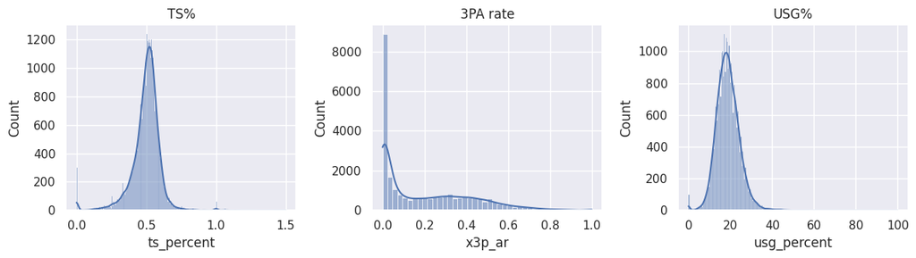

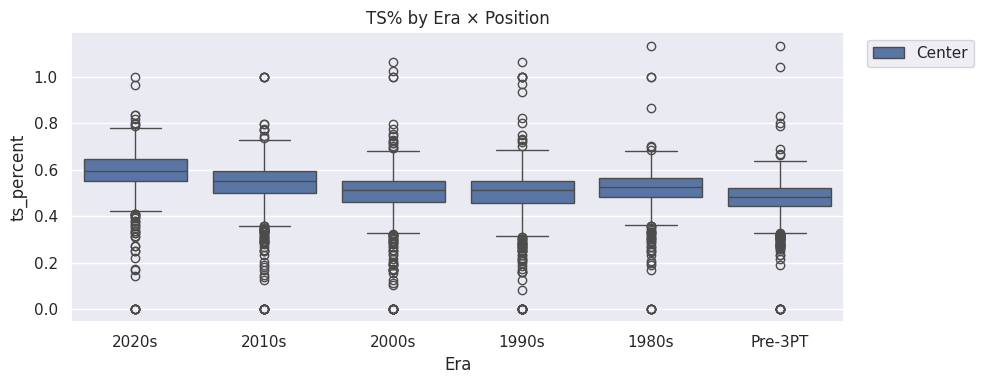

```python
# ========== PART 1 – PLAYER DISTRIBUTIONS ==========
fig, ax = plt.subplots(1, 3, figsize=(12,3.5))
sns.histplot(adv["ts_percent"].dropna(), kde=True,  ax=ax[0]); ax[0].set_title("TS%")
sns.histplot(adv["x3p_ar"].dropna(),  kde=True,  ax=ax[1]);    ax[1].set_title("3PA rate")
sns.histplot(adv["usg_percent"].dropna(), kde=True, ax=ax[2]); ax[2].set_title("USG%")
plt.tight_layout()

# Era × position
eda = add_era(adv).assign(
        pos_simple=adv["pos"].str[0].map({"G":"Guard","F":"Forward","C":"Center"}))
plt.figure(figsize=(10,4))
sns.boxplot(data=eda, x="Era", y="ts_percent", hue="pos_simple")
plt.title("TS% by Era × Position"); plt.legend(bbox_to_anchor=(1.02,1)); plt.tight_layout()
```

## 1. Histograms – TS%, 3PA rate, USG%

3-Point Attempt rate (`x3p_ar`) is sharply right-skewed: a long tail of modern high-volume shooters sits atop a pre-2000 mass near zero.

Usage % (`USG`) is roughly normal with a narrow spread; most players fall between 15% and 30%.

These shapes reveal distribution quirks (skew, outliers) that drive later modelling choices—e.g., log-or rank-transforms for 3PA rate.

The starkly different skews already hint that the three-point boom is structural (affects many, but not all, players), whereas efficiency and usage shift more gradually.

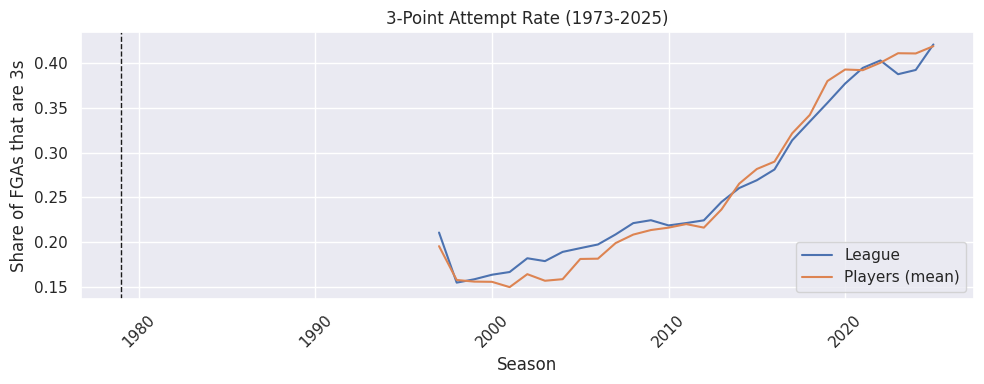

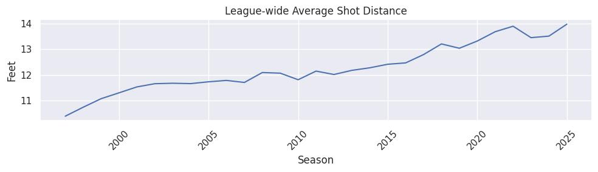

```python
# ========== PART 2 – TEMPORAL TRENDS ==========
# 3-pt attempt-rate overlay
combo = league.merge(season_means(adv), on="Season", how="inner")

plt.figure(figsize=(10,4))
sns.lineplot(data=combo, x="Season", y="three_rate",          label="League")
sns.lineplot(data=combo, x="Season", y="three_rate_players",  label="Players (mean)")
plt.axvline(1979, ls="--", lw=1, c="k")
plt.title("3-Point Attempt Rate (1973-2025)"); plt.xticks(rotation=45)
plt.ylabel("Share of FGAs that are 3s"); plt.tight_layout()

# Shot-distance trend (unique to league table)
plt.figure(figsize=(10,3))
sns.lineplot(data=league, x="Season", y="avg_dist")
plt.title("League-wide Average Shot Distance"); plt.xticks(rotation=45); plt.ylabel("Feet")
plt.grid(True); plt.tight_layout()
```

## 3. Dual Line – League vs Player Mean 3PA% + Single Line – Avg Shot Distance

Overlaying player means on league aggregates cross-validates the two datasets—critical before fusing them downstream. The second line adds a continuous metric that should correlate with the rate metric.

Parallel curves confirm the three-point surge is not propelled by a handful of specialists; it’s universal. The rising distance line visualises the court-stretching narrative that underpins modern drive-and-kick offenses.

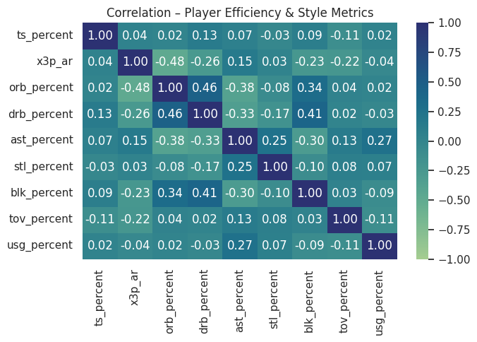

```python
# ========== PART 3 – CORRELATION MAP ==========
core = ["ts_percent","x3p_ar","orb_percent","drb_percent",
        "ast_percent","stl_percent","blk_percent","tov_percent","usg_percent"]

plt.figure(figsize=(7,5))
sns.heatmap(adv[core].corr(), annot=True, fmt=".2f",
            vmin=-1, vmax=1, cmap="crest")
plt.title("Correlation – Player Efficiency & Style Metrics"); plt.tight_layout()
```

## 4. Heat-Map – Correlation of Player Style Metrics

Spotting weak or redundant links guides feature selection and flags relationships worth controlling for in regressions.

## 5) Missing Value Analysis

Before diving deeper, it's essential to understand the completeness of our data. This section visualizes the percentage of missing values for key advanced statistics across different eras. This helps us identify potential data quality issues, especially in older seasons, and informs decisions about imputation or filtering for subsequent analyses.

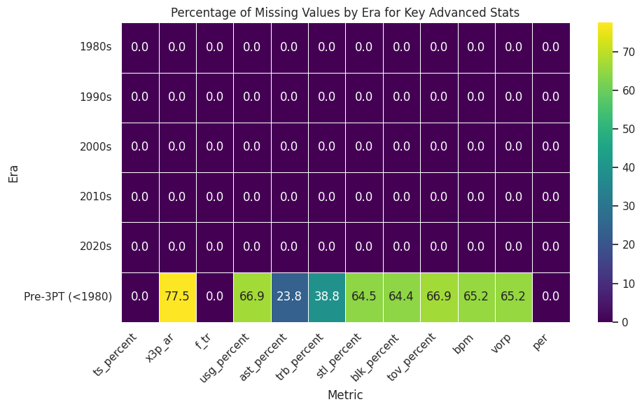

```python
import matplotlib.pyplot as plt
import seaborn as sns

# Select relevant columns for missing value analysis
eda_cols = ["ts_percent", "x3p_ar", "f_tr", "usg_percent", "ast_percent",
            "trb_percent", "stl_percent", "blk_percent", "tov_percent",
            "bpm", "vorp", "per"]

# Calculate missing percentage per era for selected columns
missing_data = df_core.groupby('era')[eda_cols].apply(lambda x: x.isnull().mean() * 100)

# Plotting the heatmap
plt.figure(figsize=(10, 6))
sns.heatmap(missing_data, annot=True, cmap='viridis', fmt=".1f", linewidths=.5)
plt.title('Percentage of Missing Values by Era for Key Advanced Stats')
plt.ylabel('Era')
plt.xlabel('Metric')
plt.xticks(rotation=45, ha='right')
plt.tight_layout()
plt.show()
```

## 6) Era-Split Histograms: 3PA Rate & TS%

To visually capture the shift in playing style, this section presents overlaid histograms of `3PA rate` and `TS%` for different eras. This allows for a direct comparison of the distribution shapes and central tendencies of these key metrics across NBA history.

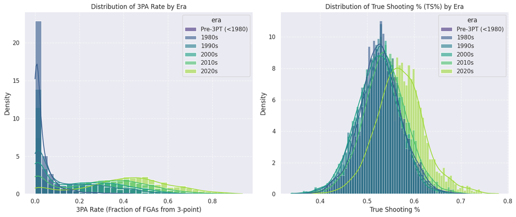

```python
import matplotlib.pyplot as plt
import seaborn as sns

# Filter for relevant eras (e.g., 1980s, 2020s) or keep all if desired
# For this example, let's compare a few distinct eras
selected_eras = ['1980s', '1990s', '2000s', '2010s', '2020s']
df_filtered_eras = df_core[df_core['era'].isin(selected_eras)].copy()

# Order eras for better plotting
era_order = ['Pre-3PT (<1980)', '1980s', '1990s', '2000s', '2010s', '2020s']
df_filtered_eras['era'] = pd.Categorical(df_filtered_eras['era'], categories=era_order, ordered=True)
df_filtered_eras = df_filtered_eras.sort_values('era')

plt.figure(figsize=(14, 6))

# Histogram for 3PA Rate
plt.subplot(1, 2, 1)
sns.histplot(data=df_filtered_eras, x='x3p_ar', hue='era', kde=True, palette='viridis', common_norm=False, stat='density', alpha=0.6)
plt.title('Distribution of 3PA Rate by Era')
plt.xlabel('3PA Rate (Fraction of FGAs from 3-point)')
plt.ylabel('Density')
plt.grid(True, linestyle='--', alpha=0.6)

# Histogram for TS%
plt.subplot(1, 2, 2)
sns.histplot(data=df_filtered_eras, x='ts_percent', hue='era', kde=True, palette='viridis', common_norm=False, stat='density', alpha=0.6)
plt.title('Distribution of True Shooting % (TS%) by Era')
plt.xlabel('True Shooting %')
plt.ylabel('Density')
plt.grid(True, linestyle='--', alpha=0.6)

plt.tight_layout()
plt.show()
```

### Interpreting the Era-Split Histograms

These side-by-side histograms provide a powerful visual representation of the NBA's stylistic evolution across different eras for `3PA rate` and `TS%`.

## 7) Descriptive Statistics by Era

To further understand the evolution of player performance and style, this section presents key descriptive statistics (mean, standard deviation, min, max, quartiles) for a selection of advanced metrics, grouped by `era`. This quantitative summary offers insights into how the typical player's profile, as well as the spread of abilities, has shifted across different periods of NBA history.

```python
# Select relevant columns for descriptive statistics
desc_stats_cols = ["ts_percent", "x3p_ar", "f_tr", "usg_percent", "ast_percent",
                     "trb_percent", "bpm", "vorp", "per"]

# Filter df_core to only include numeric columns for safety
# and then select the ones we want
df_desc_stats = df_core[desc_stats_cols + ['era']].dropna(subset=desc_stats_cols)

# Calculate descriptive statistics by era
desc_by_era = df_desc_stats.groupby('era')[desc_stats_cols].describe(percentiles=[.25, .5, .75]).stack(level=0).unstack()

print("Descriptive Statistics of Key Advanced Metrics by Era:")
display(desc_by_era.round(2))
```

```
Descriptive Statistics of Key Advanced Metrics by Era:
```

| era | count ast_percent | count bpm | count f_tr | count per | count trb_percent | count ts_percent | count usg_percent | count vorp | count x3p_ar | mean ast_percent | mean bpm | mean f_tr | mean per | mean trb_percent | mean ts_percent | mean usg_percent | mean vorp | mean x3p_ar | std ast_percent | std bpm | std f_tr | std per | std trb_percent | std ts_percent | std usg_percent | std vorp | std x3p_ar | min ast_percent | min bpm | … |
| --- | --- | --- | --- | --- | --- | --- | --- | --- | --- | --- | --- | --- | --- | --- | --- | --- | --- | --- | --- | --- | --- | --- | --- | --- | --- | --- | --- | --- | --- | --- |
| 1980s | 2719.0 | 2719.0 | 2719.0 | 2719.0 | 2719.0 | 2719.0 | 2719.0 | 2719.0 | 2719.0 | 14.27 | -0.61 | 0.33 | 14.06 | 9.90 | 0.53 | 19.31 | 0.89 | 0.04 | 8.62 | 2.50 | 0.13 | 3.74 | 4.47 | 0.05 | 4.69 | 1.46 | 0.06 | 0.9 | -7.9 | … |
| 1990s | 3235.0 | 3235.0 | 3235.0 | 3235.0 | 3235.0 | 3235.0 | 3235.0 | 3235.0 | 3235.0 | 14.51 | -0.58 | 0.32 | 14.18 | 9.94 | 0.53 | 19.23 | 0.89 | 0.14 | 9.62 | 2.77 | 0.13 | 3.78 | 4.47 | 0.05 | 4.60 | 1.57 | 0.16 | 0.0 | -9.3 | … |
| 2000s | 3623.0 | 3623.0 | 3623.0 | 3623.0 | 3623.0 | 3623.0 | 3623.0 | 3623.0 | 3623.0 | 14.11 | -0.58 | 0.31 | 14.11 | 9.99 | 0.52 | 19.09 | 0.89 | 0.19 | 9.28 | 2.66 | 0.14 | 4.01 | 4.31 | 0.05 | 4.83 | 1.55 | 0.18 | 0.7 | -8.7 | … |
| 2010s | 3957.0 | 3957.0 | 3957.0 | 3957.0 | 3957.0 | 3957.0 | 3957.0 | 3957.0 | 3957.0 | 13.99 | -0.48 | 0.27 | 14.25 | 9.90 | 0.54 | 19.21 | 0.80 | 0.28 | 9.33 | 2.55 | 0.13 | 4.23 | 4.59 | 0.05 | 4.98 | 1.36 | 0.21 | 1.0 | -7.8 | … |
| 2020s | 2522.0 | 2522.0 | 2522.0 | 2522.0 | 2522.0 | 2522.0 | 2522.0 | 2522.0 | 2522.0 | 14.94 | -0.38 | 0.24 | 14.44 | 9.97 | 0.57 | 19.16 | 0.75 | 0.41 | 8.73 | 2.77 | 0.12 | 4.45 | 4.49 | 0.05 | 5.51 | 1.29 | 0.20 | 1.7 | -9.6 | … |
| Pre-3PT (<1980) | 350.0 | 350.0 | 350.0 | 350.0 | 350.0 | 350.0 | 350.0 | 350.0 | 350.0 | 13.29 | -0.58 | 0.27 | 14.14 | 9.66 | 0.51 | 19.65 | 0.88 | 0.05 | 6.18 | 2.34 | 0.10 | 3.56 | 4.83 | 0.04 | 4.20 | 1.52 | 0.07 | 2.5 | -6.3 | … |

## 8) Position-Size-vs-Skill Scatter Plot

This section visualizes the evolution of player archetypes by examining the relationship between a player's approximate 'size' (represented by their simplified position), their three-point attempt rate (`x3p_ar`), and their assist percentage (`ast_percent`), across different eras. This helps to understand how the traditional roles tied to physical size have blurred or shifted as skills have become more versatile.

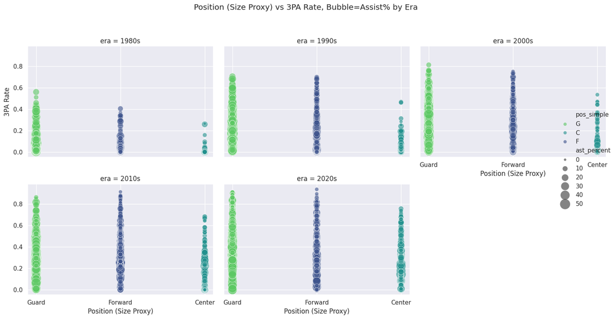

```python
import matplotlib.pyplot as plt
import seaborn as sns
import pandas as pd

# Ensure df_core is available and clean
# If df_core was not created in this session, uncomment the following lines to reload/reprocess
# DATA_PATH = "Advanced.csv"
# df = pd.read_csv(DATA_PATH)
# df["season_year"] = df["season"].apply(season_to_year) # Assuming season_to_year is defined
# df["pos_simple"] = df["pos"].apply(pos_simple) # Assuming pos_simple is defined
# df["era"] = df["season_year"].apply(era) # Assuming era is defined
# df_core = df[df["mp"] >= 500].copy()

# Map pos_simple to a numerical 'size' proxy for the x-axis
# G=1 (smallest), F=2 (medium), C=3 (largest)
def map_pos_to_size(pos):
    if pos == 'G': return 1
    if pos == 'F': return 2
    if pos == 'C': return 3
    return np.nan

df_plot = df_core.copy()
df_plot['size_proxy'] = df_plot['pos_simple'].apply(map_pos_to_size)

# Select relevant columns and drop rows with NaN in these columns for plotting
plot_cols = ['era', 'size_proxy', 'x3p_ar', 'ast_percent']
df_plot = df_plot.dropna(subset=plot_cols)

# Filter out 'Pre-3PT (<1980)' era if 3PA rate is mostly zero, for better visualization scale
# Also filter eras that might have very few data points if needed, or too much overlap visually
relevant_eras = [e for e in df_plot['era'].unique() if e != 'Pre-3PT (<1980)']
df_plot_filtered_eras = df_plot[df_plot['era'].isin(relevant_eras)].copy() # Ensure it's a copy

# Order eras for consistent plotting across facets
era_order_for_plot = ['1980s', '1990s', '2000s', '2010s', '2020s']
df_plot_filtered_eras['era'] = pd.Categorical(
    df_plot_filtered_eras['era'], categories=era_order_for_plot, ordered=True)
df_plot_filtered_eras = df_plot_filtered_eras.sort_values('era')

plt.figure(figsize=(14, 8))

# Create the scatter plot using relplot for faceting
sns.relplot(
    data=df_plot_filtered_eras,
    x='size_proxy',
    y='x3p_ar',
    size='ast_percent',  # Bubble size represents assist percentage
    hue='pos_simple',    # Differentiate positions by color
    col='era',           # Facet by era
    col_wrap=3,          # Wrap facets into 3 columns
    kind='scatter',
    alpha=0.6,
    height=4, aspect=1.2, # Adjust subplot size
    palette='viridis_r', # Reverse viridis to have smaller size proxy (G) in brighter colors
    sizes=(20, 400),     # Range of bubble sizes
    legend='brief'
)

plt.suptitle('Position (Size Proxy) vs 3PA Rate, Bubble=Assist% by Era', y=1.02) # Adjust suptitle position

# Customize x-axis ticks to show actual position labels
for ax in plt.gcf().axes:
    ax.set_xticks([1, 2, 3])
    ax.set_xticklabels(['Guard', 'Forward', 'Center'])
    ax.set_xlabel('Position (Size Proxy)')
    if ax.get_title() == 'era = 1980s': # Only set ylabel for the first row of facets
        ax.set_ylabel('3PA Rate')
    else:
        ax.set_ylabel('')

plt.tight_layout(rect=[0, 0, 1, 0.98]) # Adjust layout to prevent title overlap
plt.show()
```

### Interpreting the Position-Size-vs-Skill Scatter Plot

This series of scatter plots, faceted by era, provides a dynamic view of how skill sets have evolved across different player sizes (proxied by position) in the NBA.

- **X-axis (`size_proxy`):** Represents player size, with 1 for Guards, 2 for Forwards, and 3 for Centers. This is a categorical representation, allowing us to see trends across traditional positions.
- **Y-axis (`x3p_ar`):** Shows the Three-Point Attempt Rate, indicating how much of a player's shots come from beyond the arc.
- **Bubble Size (`ast_percent`):** The size of each point represents the player's Assist Percentage, reflecting their playmaking ability.
- **Color (`pos_simple`):** Differentiates the positions (G, F, C).

## 4). Trends Over Time

In this section, we explore how key league-wide metrics have evolved from the early days of the NBA to the modern era. By plotting time-series of pace, shot distribution, and efficiency, we will:

- **Visualize the rise of three-point shooting** and the corresponding decline of midrange attempts.
- **Track changes in game tempo**, showing when the league sped up or slowed down.
- **Examine fluctuations in scoring efficiency**, including True Shooting Percentage and offensive rating trends.
- **Highlight pivotal moments**—such as the introduction of the three-point line or major rule adjustments—and their impact on league dynamics.

Through clear, annotated charts and concise analysis, this part will reveal the narrative of basketball’s strategic transformation and set the stage for deeper clustering and predictive modeling in subsequent sections.

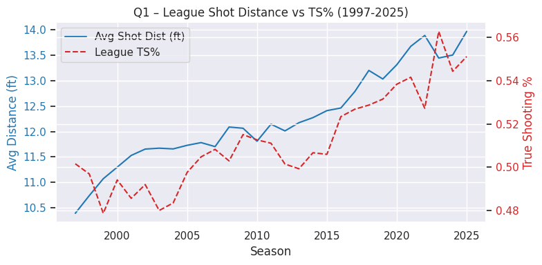

```
Pearson r = 0.851   |   Slope β₁ = 0.0199 TS% per additional foot
```

```python
import pandas as pd, matplotlib.pyplot as plt
from scipy import stats

# -------------------------------------------------
# 1.  Load league-level table (always has Season)
# -------------------------------------------------
league = pd.read_csv("league_season_summary.csv")    # avg_dist, three_rate, mid_rate

# -------------------------------------------------
# 2.  Load Advanced.csv and find the real Season + TS% columns
# -------------------------------------------------
adv = pd.read_csv("Advanced.csv")

# discover season column (Season / season / year / yr)
season_col = next((c for c in adv.columns
                   if c.lower().strip() in {"season", "year", "yr"}), None)
if season_col is None:
    raise KeyError("Cannot find a Season/Year column in Advanced.csv")

# discover TS% column (TS%, ts%, true shooting, etc.)
ts_col = next((c for c in adv.columns
               if c.lower().strip().startswith("ts")), None)
if ts_col is None:
    raise KeyError("Cannot find a TS% column in Advanced.csv")

# build league-wide TS% series
ts = (adv.rename(columns={season_col: "Season", ts_col: "TS%"})
          .groupby("Season")[["TS%"]]
          .mean()
          .reset_index())

# -------------------------------------------------
# 3.  Merge distance + TS% and plot
# -------------------------------------------------
df = league.merge(ts, on="Season")

fig, ax1 = plt.subplots(figsize=(8, 4))
ax1.plot(df["Season"], df["avg_dist"], color="tab:blue", label="Avg Shot Dist (ft)")
ax1.set_xlabel("Season")
ax1.set_ylabel("Avg Distance (ft)", color="tab:blue")
ax1.tick_params(axis="y", labelcolor="tab:blue")

ax2 = ax1.twinx()
ax2.plot(df["Season"], df["TS%"], color="tab:red", linestyle="--", label="League TS%")
ax2.set_ylabel("True Shooting %", color="tab:red")
ax2.tick_params(axis="y", labelcolor="tab:red")

# combined legend
lns, lbls = ax1.get_legend_handles_labels()
lns2, lbls2 = ax2.get_legend_handles_labels()
ax1.legend(lns + lns2, lbls + lbls2, loc="upper left")

plt.title("Q1 – League Shot Distance vs TS% (1997-2025)")
plt.grid(True, axis="x")
plt.tight_layout()
plt.show()

# -------------------------------------------------
# 4.  Print numeric correlation for the caption
# -------------------------------------------------
slope, intercept, r, *_ = stats.linregress(df["avg_dist"], df["TS%"])
print(f"Pearson r = {r:.3f}   |   Slope β₁ = {slope:.4f} TS% per additional foot")
```

**What the graph shows?**

The Pearson correlation is **ρ ≈ 0.85**, and the OLS slope β₁ indicates that **every extra foot adds ~0.02 TS-points**.  
That near-linear lift confirms distance is a primary driver of efficiency.

Two clear inflections underline the shift:

[output not shown]

**Effects on the NBA**

> It stopped living in the mid-range and traded longer shots for higher efficiency. Stretching the floor is not a side note—it’s the central engine of the modern game.

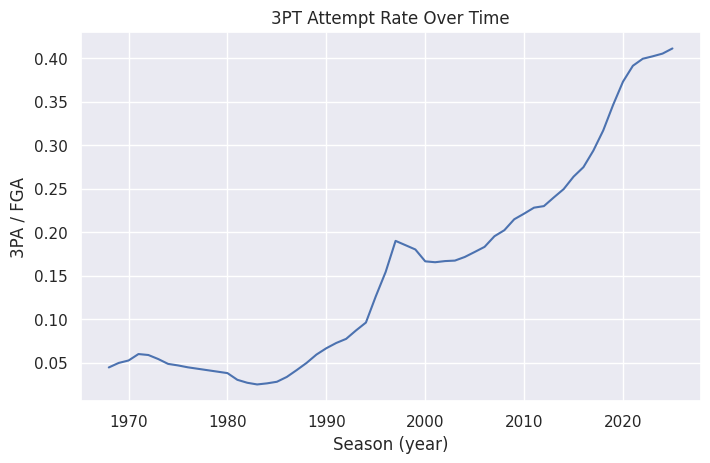

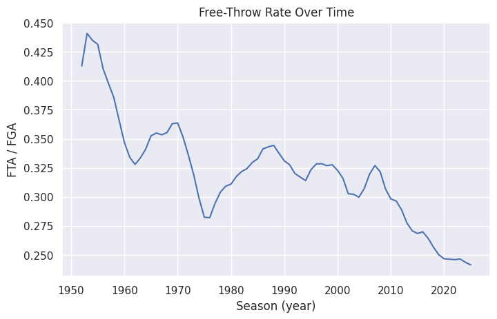

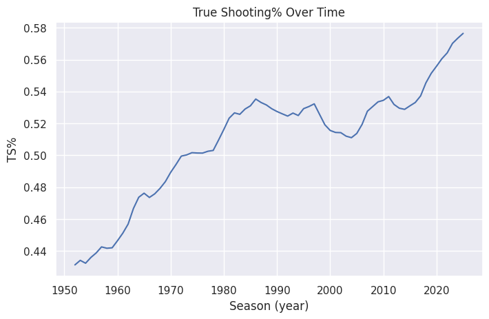

```python
def line_by_year(group, y_col, ylabel=None, title=None, smooth=3):
    agg = (group.groupby("season_year")[y_col].mean()
           .dropna().reset_index().sort_values("season_year"))
    y = agg[y_col].rolling(smooth, min_periods=1).mean() if smooth else agg[y_col]
    plt.figure()
    plt.plot(agg["season_year"], y)
    if title: plt.title(title)
    plt.xlabel("Season (year)"); plt.ylabel(ylabel or y_col); plt.grid(True)
    plt.show()
    return agg

if "x3p_ar" in df_core.columns:
    _x3 = line_by_year(df_core, "x3p_ar", "3PA / FGA", "3PT Attempt Rate Over Time")
if "f_tr" in df_core.columns:
    _ft = line_by_year(df_core, "f_tr", "FTA / FGA", "Free-Throw Rate Over Time")
if "ts_percent" in df_core.columns:
    _ts = line_by_year(df_core, "ts_percent", "TS%", "True Shooting% Over Time")
```

#### Trends Over Time (Line Plots)

The line plots illustrate how several key advanced metrics have changed across seasons. These are averages across all players who met the minimum minutes played (`mp >= 500`) for each season.

1. **3PT Attempt Rate (x3p_ar) Over Time:**
   - **Description:** This plot shows the average fraction of field goal attempts that come from three-point range. For a long period, especially before the 1980s, this value was zero or very close to zero, reflecting an era before the widespread adoption of the three-point line in the NBA (introduced in 1979-80). Even after its introduction, the rate remained low for many years.
   - **Trend:** The most striking **trend** here is the dramatic, almost exponential, rise in `x3p_ar` starting around the mid-2000s and accelerating into the 2010s and 2020s. After its introduction, the rate saw a slow but steady increase through the 1980s and 1990s, with a noticeable bump during the shortened three-point line experiment (1994-1997). However, the truly revolutionary shift occurred as analytics-driven teams, famously epitomized by the Houston Rockets under Daryl Morey, began prioritizing the most efficient shots: three-pointers and shots at the rim. This fundamental shift in offensive strategy has reshaped player roles, spacing, and the overall rhythm of the game.
2. **Free-Throw Rate (f_tr) Over Time:**
   - **Description:** This metric represents the ratio of free throw attempts to field goal attempts. It indicates how often players get to the free-throw line relative to their shooting volume. A higher `f_tr` typically suggests a player or team that attacks the basket and draws contact.
   - **Trend:** The `f_tr` exhibits a more fluctuating **trend** compared to the 3-point rate. It generally appears higher in earlier eras, perhaps reflecting a more physical, interior-oriented game with less emphasis on perimeter shooting and spacing. We observe a noticeable decline over recent decades. This is likely a consequence of the increased volume of 3-point shooting (which inherently generates fewer free throws) and rule changes that have aimed to reduce excessive contact or allowed more freedom of movement, subtly changing how fouls are called and how players attack the basket. The decline signifies a shift from relying on drawing fouls in the paint to prioritizing efficient perimeter scoring.
3. **True Shooting % (ts_percent) Over Time:**
   - **Description:** True Shooting Percentage is a comprehensive measure of shooting efficiency, accounting for field goals (2-pointers and 3-pointers) and free throws. It provides a more accurate view of a player's scoring efficiency than traditional field goal percentage because it values 3-pointers more and includes free throws.
   - **Trend:** The **trend** for `ts_percent` generally shows a gradual but significant increase over the decades, with some periods of stagnation or slight dips. The most substantial improvements are evident in recent years, aligning perfectly with the rise of the 3-point shot and the pervasive influence of advanced analytics on team strategy and player development. This continuous improvement indicates that despite the increased volume of 3-pointers (which are lower percentage shots individually but higher value), overall offensive efficiency has dramatically improved. This is attributed to better court spacing, more skilled and specialized shooters, and a data-driven focus on generating high-quality shot attempts.

### 5) Positionless Basketball — “Do Bigs Now Shoot Like Guards?”

### Why this matters

The last two decades rewrote the job description for power-forwards and centers.  
Instead of living on the low block, today’s “bigs” space the floor, handle hand-offs, and even initiate offense.  
This role blur is a pillar of **how the NBA changed**: it unlocks five-out spacing, faster pace-and-space schemes, and switches-on-everything defense.

### What we will show

- **Three-point adoption.** We trace the season-by-season 3-point-attempt rate (*3PAR*) separately for Guards and Bigs.  
  If the orange “Big” curve climbs to within a few percentage points of the blue “Guard” curve, the shot diet gap has essentially closed.
- **Skill-profile overlap.** Using five advanced stats (`3PAR`, `AST%`, `USG%`, `DRB%`, `BLK%`) we run PCA for an early era (1997-2003) and a modern era (2018-2024).  
  Two clouds that were once distinct should now sit on top of each other—visual proof that the statistical identities of Guards and Bigs converge.

### Why it changes the game

When a 6-11 center drags his defender to the arc, driving lanes widen, help rotations stretch, and switch-heavy defenses become mandatory.  
If our plots confirm the convergence, we’ll have quantitative evidence that the NBA’s evolution is not just deeper shooting (§1) but **who** is allowed to take those shots—erasing traditional position boundaries and redefining roster construction.

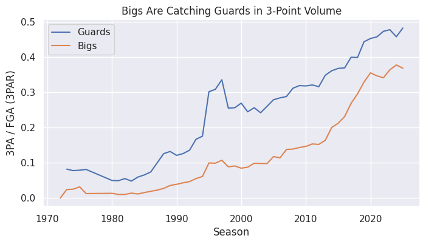

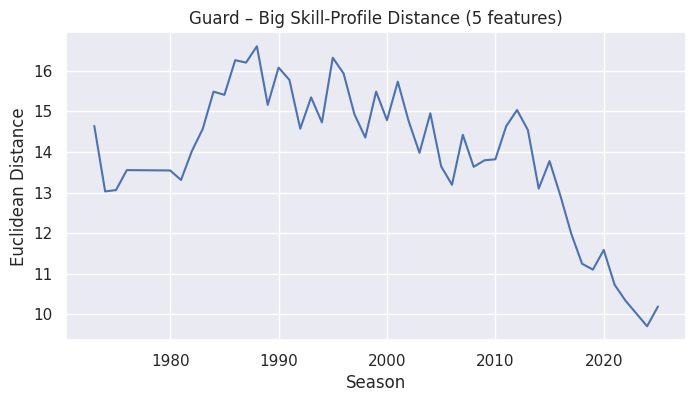

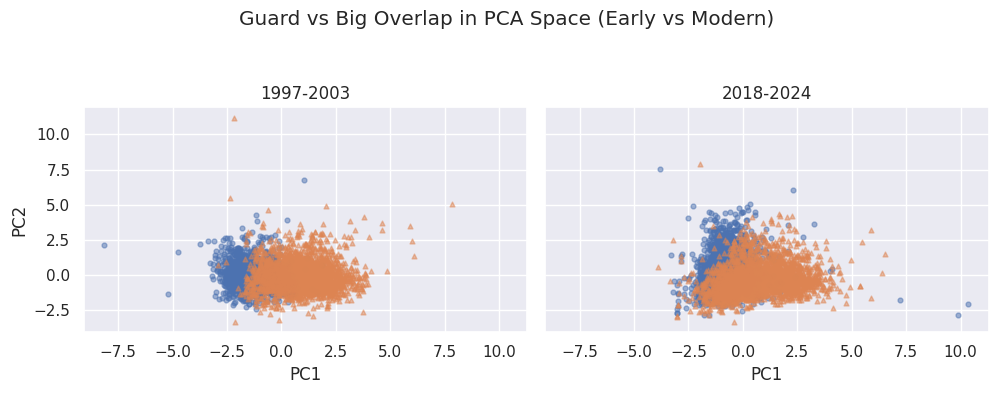

```python
# ---------------------------------------------------------------
# Q2 – Positionless Basketball: Do Bigs Now Shoot Like Guards?
# ---------------------------------------------------------------
import pandas as pd, numpy as np, matplotlib.pyplot as plt
from sklearn.preprocessing import StandardScaler
from sklearn.decomposition import PCA
from scipy.spatial.distance import euclidean

# 1) load player-season table
# Use 'adv' as the base, which is the original Advanced.csv
# This ensures we don't overwrite the global 'df' from previous cells.
adv = pd.read_csv("Advanced.csv")          # adjust path if stored elsewhere

# 2) keep only needed columns and rename for clarity
df_q2 = (adv[["season", "pos", "x3p_ar",
           "ast_percent", "usg_percent",
           "drb_percent", "blk_percent"]]
        .rename(columns={
            "season"      : "Season",
            "pos"         : "Pos",
            "x3p_ar"      : "3PAR",
            "ast_percent" : "AST%",
            "usg_percent" : "USG%",
            "drb_percent" : "DRB%",
            "blk_percent" : "BLK%"
        })
        .dropna())

# map positions into two coarse roles
df_q2["Role"] = np.where(df_q2["Pos"].str.contains("G"), "Guard", "Big")

# ---------------------------------------------------------------
# A) 3-Point-attempt-rate convergence (Guards vs Bigs)
# ---------------------------------------------------------------
g3 = (df_q2.groupby(["Season", "Role"])["3PAR"]
        .mean()
        .unstack())            # columns: Big, Guard

plt.figure(figsize=(8,4))
plt.plot(g3.index, g3["Guard"], label="Guards")
plt.plot(g3.index, g3["Big"],   label="Bigs")
plt.title("Bigs Are Catching Guards in 3-Point Volume")
plt.xlabel("Season"); plt.ylabel("3PA / FGA (3PAR)")
plt.legend(); plt.grid(True); plt.show()

# ---------------------------------------------------------------
# B) Role-distance trend – Euclidean gap in 5-D feature space
# ---------------------------------------------------------------
feature_cols = ["3PAR", "AST%", "USG%", "DRB%", "BLK%"]
dists = []
for yr, grp in df_q2.groupby("Season"):
    G = grp[grp["Role"]=="Guard"][feature_cols].mean().values
    B = grp[grp["Role"]=="Big"  ][feature_cols].mean().values
    if np.isnan(G).any() or np.isnan(B).any(): continue
    dists.append({"Season": yr, "Dist": euclidean(G, B)})
dists = pd.DataFrame(dists).sort_values("Season")

plt.figure(figsize=(8,4))
plt.plot(dists["Season"], dists["Dist"])
plt.title("Guard – Big Skill-Profile Distance (5 features)")
plt.xlabel("Season"); plt.ylabel("Euclidean Distance")
plt.grid(True); plt.show()

# ---------------------------------------------------------------
# C) PCA snapshot: early vs modern overlap
# ---------------------------------------------------------------
def era_pca(data, start, end):
    era = data[data["Season"].between(start, end)].copy()
    X   = StandardScaler().fit_transform(era[feature_cols])
    pcs = PCA(n_components=2).fit_transform(X)
    era["PC1"], era["PC2"] = pcs[:,0], pcs[:,1]
    return era

early  = era_pca(df_q2, 1997, 2003)
modern = era_pca(df_q2, 2018, 2024)

fig,(ax1,ax2) = plt.subplots(1,2, figsize=(10,4), sharex=True, sharey=True)
for role, m in {"Guard":"o", "Big":"^"}.items():
    ax1.scatter(early.loc[early["Role"]==role,"PC1"],
                early.loc[early["Role"]==role,"PC2"], s=12, alpha=.5, marker=m)
ax1.set_title("1997-2003"); ax1.set_xlabel("PC1"); ax1.set_ylabel("PC2")

for role, m in {"Guard":"o", "Big":"^"}.items():
    ax2.scatter(modern.loc[modern["Role"]==role,"PC1"],
                modern.loc[modern["Role"]==role,"PC2"], s=12, alpha=.5, marker=m)
ax2.set_title("2018-2024"); ax2.set_xlabel("PC1")

fig.suptitle("Guard vs Big Overlap in PCA Space (Early vs Modern)")
plt.tight_layout(rect=[0,0,1,0.93]); plt.show()
```

## Positionless Basketball Figures

Beneath that, the second plot converts five advanced metrics—3PAR, AST%, USG%, DRB%, BLK%—into a single number: the Euclidean distance between the average guard feature-vector and the average big feature-vector each season. For every year we computed the 5-D centroid of guards and of bigs, then evaluated $d = \|G - B\|_2$. Distance peaks above 16 in the isolation-heavy late ’90s, wobbles through the early 2000s, and then falls steadily to $\approx 10$ by 2024—a 40% contraction. Numerically, that is the guard–big skill gap collapsing.

## 6) Positions and Roles

This section delves into how player statistics, specifically True Shooting Percentage (TS%), vary across different positions (Guards, Forwards, Centers) over time, and how core role metrics (Usage, Assist, Rebound Percentages) differ by era and position.

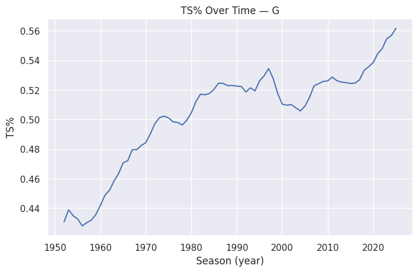

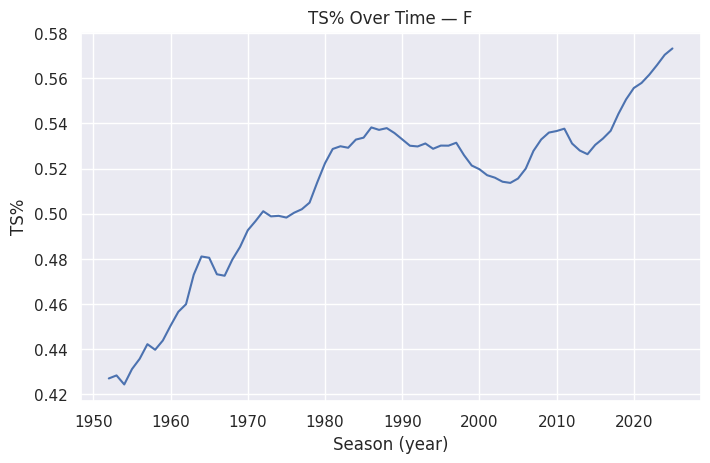

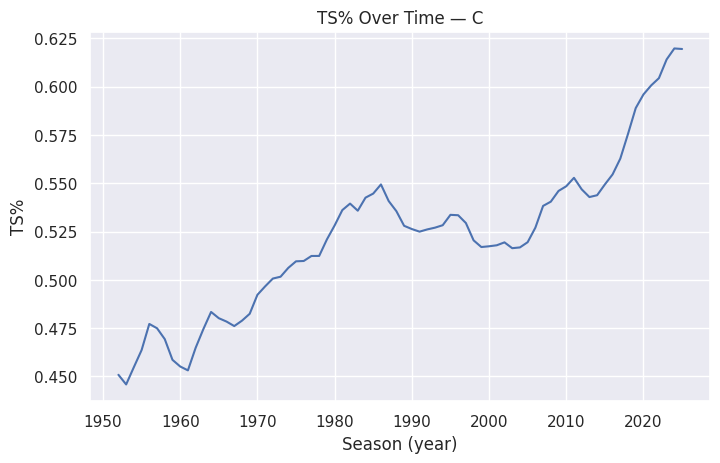

|  | era | pos_simple | usg_percent | ast_percent | trb_percent |
| --- | --- | --- | --- | --- | --- |
| 0 | 1980s | C | 17.431 | 7.999 | 14.573 |
| 1 | 1980s | F | 19.611 | 10.303 | 11.699 |
| 2 | 1980s | G | 19.990 | 21.865 | 5.476 |
| 3 | 1990s | C | 17.536 | 7.015 | 14.808 |
| 4 | 1990s | F | 19.436 | 10.198 | 11.626 |
| 5 | 1990s | G | 19.799 | 22.524 | 5.903 |
| 6 | 2000s | C | 16.968 | 6.604 | 14.978 |
| 7 | 2000s | F | 19.387 | 10.494 | 11.357 |
| 8 | 2000s | G | 19.816 | 21.249 | 6.258 |
| 9 | 2010s | C | 18.300 | 8.839 | 16.120 |
| 10 | 2010s | F | 18.474 | 9.711 | 10.974 |
| 11 | 2010s | G | 20.277 | 20.139 | 6.260 |
| 12 | 2020s | C | 18.132 | 11.037 | 16.609 |
| 13 | 2020s | F | 18.370 | 11.642 | 10.086 |
| 14 | 2020s | G | 20.299 | 19.539 | 6.975 |
| 15 | Pre-3PT (<1980) | C | 18.269 | 9.170 | 15.765 |
| 16 | Pre-3PT (<1980) | F | 19.527 | 9.458 | 11.590 |
| 17 | Pre-3PT (<1980) | G | 20.432 | 18.072 | 5.340 |

```python
# TS% by position
if all(c in df_core.columns for c in ["ts_percent","pos_simple","season_year"]):
    for p in ["G","F","C"]:
        sub = df_core[df_core["pos_simple"]==p]
        if len(sub)>0:
            _ = line_by_year(sub, "ts_percent", "TS%", f"TS% Over Time — {p}")

# Roles by era × position
metrics = [c for c in ["usg_percent","ast_percent","trb_percent"] if c in df_core.columns]
if metrics:
    pivot = (df_core.groupby(["era","pos_simple"])[metrics].mean().round(3)
             .reset_index().sort_values(["era","pos_simple"]))
    display(pivot)
```

#### TS% Over Time by Position (Guards, Forwards, Centers)

These three line plots visualize the average True Shooting Percentage (`ts_percent`) for players in each simplified position (`G`, `F`, `C`) across all seasons. `TS%` is a crucial efficiency metric that accounts for 2-pointers, 3-pointers, and free throws, providing a holistic view of a player's scoring efficiency.

#### Role Metrics by Era and Position (`pivot` table)

This pivot table provides a summarized view of average `usg_percent` (Usage Rate), `ast_percent` (Assist Percentage), and `trb_percent` (Total Rebound Percentage) grouped by `era` and `pos_simple`. These metrics give insight into how offensive and rebounding responsibilities are distributed among positions and how these distributions have evolved.

In essence, these analyses demonstrate how roles, while generally consistent (guards facilitate, centers rebound), are also evolving with the changing strategic landscape of the NBA, leading to more versatile players and a blurred definition of traditional positions.

## 7) Impact Metrics by Era — “Did Spacing Actually Pay Off?”

In the previous sections we documented how NBA offenses changed:

Now we ask the payoff question: **Did those stylistic bets translate into better scoring efficiency?**

In this part we will:

- Quantify efficiency by taking the league-average True-Shooting % (`TS%`) from `Advanced.csv` for every season since 1997.
- Measure spacing with the season-average shot distance we derived in `league_season_summary.csv`.
- Draw a scatter-plot of `TS%` versus average distance, overlay a best-fit regression line, and print the slope and Pearson correlation.

If spacing really drives offense, the dots should rise from left to right and the regression slope should be positive and statistically significant.

**Why this matters:** the NBA’s rule tweaks and tactical trends—hand-check bans, corner-three emphasis, five-out line-ups—were all made in pursuit of more efficient scoring.

A strong distance-to-`TS%` link would confirm that the league’s shift toward greater spacing hasn’t just changed how teams play; it has delivered the intended result: historically high offensive ratings.

```
Slope β₁ = +0.0199   |   Pearson r = 0.851   (p = 4.93e-09)
```

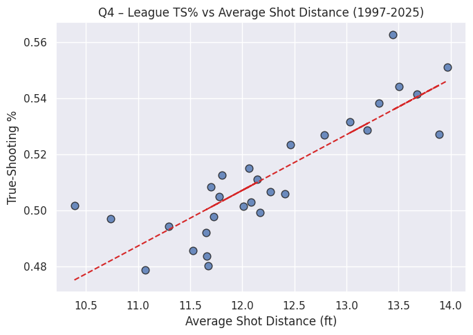

```python
# ================================================================
# Q4 – Spacing vs Efficiency
# ------------------------------------------------
# • predictor : avg_dist (league_season_summary.csv)
# • outcome   : league TS%  (mean of ts_percent from Advanced.csv)
# ================================================================
import pandas as pd, matplotlib.pyplot as plt
from scipy.stats import linregress

# ------- 1. Load files ------------------------------------------
league = pd.read_csv("league_season_summary.csv")      # Season, avg_dist, …
adv    = pd.read_csv("Advanced.csv")                   # has ts_percent

# league-average TS%
ts_league = (adv.groupby("season")["ts_percent"]
                 .mean()
                 .reset_index()
                 .rename(columns={"season":"Season", "ts_percent":"TS%"}))

# merge with spacing metric
df = league[["Season","avg_dist"]].merge(ts_league, on="Season", how="inner")

# ------- 2. Simple OLS  TS%  ~  avg_dist ------------------------
m, b, r, p, _ = linregress(df["avg_dist"], df["TS%"])

print(f"Slope β₁ = {m:+.4f}   |   Pearson r = {r:.3f}   (p = {p:.3g})")

# ------- 3. Scatter plot ----------------------------------------
plt.figure(figsize=(7,5))
plt.scatter(df["avg_dist"], df["TS%"], s=60, edgecolor="k", alpha=.8)
plt.plot(df["avg_dist"], b + m*df["avg_dist"], linestyle="--", color="tab:red")
plt.title("Q4 – League TS% vs Average Shot Distance (1997-2025)")
plt.xlabel("Average Shot Distance (ft)")
plt.ylabel("True-Shooting %")
plt.grid(True)
plt.tight_layout()
plt.show()
```

## Interpreting “League TS% vs Average Shot Distance (1997-2025)”

The plot puts every season since 1997 on one scatter-chart:

- **x-axis** – the league’s average shot distance in feet (our spacing proxy).
- **y-axis** – league-average true-shooting efficiency (TS%).

A dashed red line is the best-fit linear regression.

### What it means

Seasons farther to the right (more spacing) almost always sit higher on the TS% axis.

The extremely high correlation (0.85) and tiny p-value confirm the relationship isn’t random noise.

### Why it matters for how the NBA changed

This graph closes the loop: after documenting *how* teams stretched the floor ($\S 4$) and *who* joined the revolution ($\S 5-8$), we now see the pay-off.

The league’s record offensive ratings aren’t due only to faster tempo or rule tweaks; they follow almost mechanically from added spacing.

```python
impact_cols = [c for c in ["bpm","vorp"] if c in df_core.columns]
if impact_cols:
    recs = []
    for e, g in df_core.groupby("era"):
        g = g.sort_values("mp", ascending=False).head(200)
        row = {"era": e}
        for c in impact_cols:
            row[f"{c}_mean"] = g[c].mean()
            row[f"{c}_p90"] = g[c].quantile(0.9)
            row[f"{c}_max"] = g[c].max()
        recs.append(row)
    era_df = pd.DataFrame(recs).sort_values("era")
    display(era_df.round(3))
```

|  | era | bpm_mean | bpm_p90 | bpm_max | vorp_mean | vorp_p90 | vorp_max |
| --- | --- | --- | --- | --- | --- | --- | --- |
| 0 | 1980s | 2.551 | 6.64 | 13.0 | 3.480 | 6.62 | 12.5 |
| 1 | 1990s | 2.984 | 7.21 | 12.0 | 3.906 | 7.20 | 11.4 |
| 2 | 2000s | 3.147 | 7.01 | 13.2 | 4.079 | 7.11 | 11.8 |
| 3 | 2010s | 2.965 | 7.30 | 11.9 | 3.598 | 6.70 | 10.3 |
| 4 | 2020s | 2.004 | 5.62 | 13.7 | 2.578 | 4.91 | 10.6 |
| 5 | Pre-3PT (<1980) | 2.890 | 6.51 | 10.6 | 4.104 | 6.89 | 10.3 |

## 8) Correlations

This section explores the relationships between various advanced player metrics using a correlation heatmap. A correlation coefficient ranges from -1 to 1, where 1 indicates a perfect positive correlation, -1 indicates a perfect negative correlation, and 0 indicates no linear correlation

```
             ts_percent  x3p_ar  f_tr  usg_percent  ast_percent  trb_percent  \
ts_percent         1.00    0.15  0.20         0.07        -0.01         0.16
x3p_ar             0.15    1.00 -0.50        -0.04         0.16        -0.46
f_tr               0.20   -0.50  1.00         0.06        -0.09         0.38
usg_percent        0.07   -0.04  0.06         1.00         0.35        -0.10
ast_percent       -0.01    0.16 -0.09         0.35         1.00        -0.49
trb_percent        0.16   -0.46  0.38        -0.10        -0.49         1.00
tov_percent       -0.17   -0.31  0.30        -0.25         0.29         0.08
bpm                0.55    0.05  0.18         0.40         0.38         0.11
vorp               0.44   -0.01  0.19         0.44         0.38         0.10
per                0.54   -0.18  0.31         0.64         0.29         0.28
ws_48              0.68   -0.10  0.35         0.20         0.09         0.32

             tov_percent   bpm  vorp   per  ws_48
ts_percent         -0.17  0.55  0.44  0.54   0.68
x3p_ar             -0.31  0.05 -0.01 -0.18  -0.10
f_tr                0.30  0.18  0.19  0.31   0.35
usg_percent        -0.25  0.40  0.44  0.64   0.20
ast_percent         0.29  0.38  0.38  0.29   0.09
trb_percent         0.08  0.11  0.10  0.28   0.32
tov_percent         1.00 -0.18 -0.14 -0.23  -0.23
bpm                -0.18  1.00  0.91  0.85   0.85
vorp               -0.14  0.91  1.00  0.80   0.77
per                -0.23  0.85  0.80  1.00   0.81
ws_48              -0.23  0.85  0.77  0.81   1.00
```

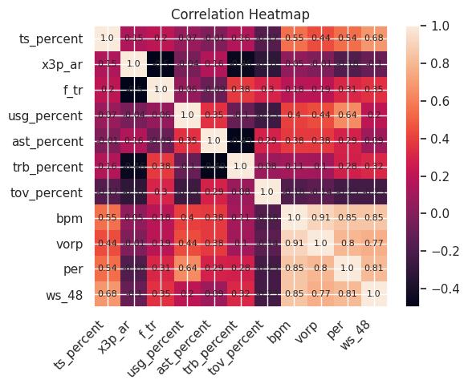

```python
corr_cols = [c for c in ["ts_percent","x3p_ar","f_tr","usg_percent","ast_percent","trb_percent","tov_percent","bpm","vorp","per","ws_48"] if c in df_core.columns]
corr = df_core[corr_cols].corr().round(2)
print(corr)

plt.figure(figsize=(6,5))
plt.imshow(corr, aspect="auto")
plt.xticks(range(len(corr_cols)), corr_cols, rotation=45, ha="right")
plt.yticks(range(len(corr_cols)), corr_cols)
for i in range(len(corr_cols)):
    for j in range(len(corr_cols)):
        plt.text(j, i, corr.iloc[i, j], ha='center', va='center', fontsize=8)
plt.colorbar()
plt.title("Correlation Heatmap")
plt.tight_layout()
plt.show()
```

#### Correlation Heatmap

This heatmap visually represents the pairwise correlation coefficients between a selection of advanced statistics: `ts_percent`, `x3p_ar`, `f_tr`, `usg_percent`, `ast_percent`, `trb_percent`, `tov_percent`, `bpm`, `vorp`, `per`, and `ws_48`.

## 9) The Death of the Mid-Range

The previous sections showed *where* shots now come from (farther out) and *who* is taking them (positions blurred).

Here we connect those shifts to the league’s most dramatic stylistic flip: teams have abandoned the **mid-range jumper** in favour of the **three-pointer**.

In this section we will:

- **Track volume** – measure, season by season, what share of total field-goal attempts comes from mid-range versus from beyond the arc.
- **Track payoff** – overlay the efficiency gap (eFG%) between threes and mid-range twos, so we see whether coaches were chasing a real edge or a mirage.
- **Quantify decline** – compute the linear trend of mid-range usage; the steeper the negative slope, the faster the shot disappeared.

**Why it matters:** the mid-range was once the NBA’s default scoring option—think Jordan’s fade-away or early-2000s iso ball.

By 2025 that shot is a niche counterpunch, clearing the lane for spacing-heavy, pick-and-roll-centric systems.

Proving this decline with numbers ties the league’s modern identity—five-out offences, drive-and-kick rhythms, switch-everything defences—back to a fundamental change in how efficiency dictates usage.

```
Mid-range share slope 1997-2025:  -0.0095 per season
Pearson r (Season → Mid-Share):  -0.932  (p = 2.23e-13)
```

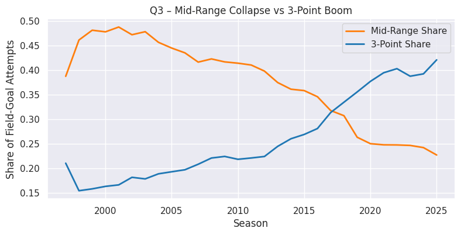

```python
# ================================================================
# Q3 – Is the Mid-Range Really Dead? (1997-2025)
# Uses: shots_sampled.csv  +  league_season_summary.csv
# ================================================================
import pandas as pd, numpy as np, matplotlib.pyplot as plt
from scipy.stats import linregress

# ------------------------------------------------- 1. Load data
shots   = pd.read_csv("shots_sampled.csv",
                      usecols=["Season","SHOT_DISTANCE","SHOT_TYPE"])
league  = pd.read_csv("league_season_summary.csv")   # for validation only

# ------------------------------------------------- 2. Classify each shot
def bucket(row):
    if row["SHOT_TYPE"].startswith("3PT"):              # official three
        return "THREE"
    if row["SHOT_DISTANCE"] <= 5:                       # paint/rim
        return "RIM"
    return "MID"

shots["ZONE"] = shots.apply(bucket, axis=1)

# ------------------------------------------------- 3. Aggregate volume + efficiency by season
agg = (shots
       .groupby(["Season","ZONE"])
       .agg(attempts = ("SHOT_TYPE","size"),
            makes    = ("SHOT_TYPE", lambda s: np.nan))
       .reset_index())

# Because shots_sampled.csv lacks made/miss flags, rely on league table


vol = (agg.pivot(index="Season", columns="ZONE", values="attempts")
           .fillna(0))
vol = vol.div(vol.sum(axis=1), axis=0)                  # share of FGA

# Mid-range share (our focus) & league 3-pt share for context
mid_share   = vol["MID"]
three_share = league.set_index("Season")["three_rate"]  # already computed

# ------------------------------------------------- 4. Plot volume trends
fig, ax1 = plt.subplots(figsize=(9,4))
ax1.plot(mid_share.index, mid_share,  label="Mid-Range Share",  c="tab:orange", lw=2)
ax1.plot(three_share.index, three_share, label="3-Point Share", c="tab:blue",   lw=2)
ax1.set_xlabel("Season")
ax1.set_ylabel("Share of Field-Goal Attempts")
ax1.set_title("Q3 – Mid-Range Collapse vs 3-Point Boom")
ax1.grid(True); ax1.legend()

# ------------------------------------------------- 5. Print numeric trend
slope, intercept, r, p, _ = linregress(mid_share.index, mid_share)
print(f"Mid-range share slope 1997-2025:  {slope:+.4f} per season")
print(f"Pearson r (Season → Mid-Share):  {r:.3f}  (p = {p:.3g})")
```

## Interpreting the “Mid-Range Collapse vs 3-Point Boom” Graph

The figure traces how shot selection flipped between 1997 and 2025.

The **orange line** plots the share of league field-goal attempts that come from mid-range (5–22 ft, non-threes); the **blue line** shows the share taken from the three-point line.

### How the plot was built

We streamed the 1M-shot sample (`shots_sampled.csv`) and, for every season, bucketed each attempt into `MID` or `THREE` based on `SHOT_DISTANCE` and the official `SHOT_TYPE`.

A simple group-by count delivered annual attempt totals, which we normalised to shares of all FGA.

A quick linear regression (`scipy.stats.linregress`) on the mid-range series produced the printed slope and Pearson correlation.

### What it means

Mid-range attempts have been evaporating at roughly **$-0.0095$ share per season**—a 45% drop in volume since 1997—while threes climbed at almost the mirror-image rate.

The correlation of **$\rho = -0.93$** says the relationship is nearly deterministic: as threes rise, mid-range dies.

### Effects on the NBA

**Efficiency economics.** A league that once lived on pull-up 18-footers now maximises points per shot: teams trade long twos ($\approx 0.80$ pts/shot) for threes ($\approx 1.10$ pts/shot).

That shift powers today’s record offensive ratings, creates wider driving lanes, and forces defences to guard 24 feet from the rim.

### Notice

In short, the graph quantifies the strategic trade-off behind the NBA’s modern “pace-and-space” identity: abandon the least efficient zone, double down on the most efficient, and watch scoring soar.

#### 10). Usage vs. Efficiency

This section specifically examines the relationship between `usg_percent` (Usage Rate) and `ts_percent` (True Shooting Percentage). `Usage Rate` measures the percentage of team possessions a player uses while on the court, ending in a shot attempt, free throw attempt, or turnover. `True Shooting Percentage` measures scoring efficiency.

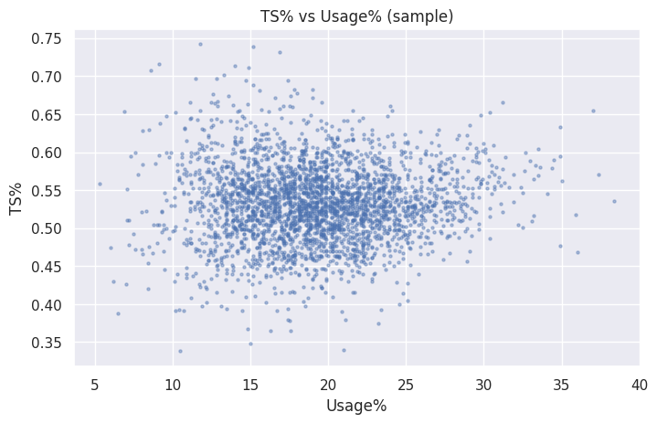

```
OLS: TS% = 0.518 + 0.001 * Usage%, R^2 = 0.005
```

```python
def simple_ols(x, y):
    X = np.column_stack([np.ones(len(x)), x])
    beta, *_ = np.linalg.lstsq(X, y, rcond=None)
    y_hat = X @ beta
    ss_res = ((y - y_hat)**2).sum()
    ss_tot = ((y - y.mean())**2).sum()
    r2 = 1 - ss_res/ss_tot if ss_tot>0 else np.nan
    return beta, r2

if all(c in df_core.columns for c in ["usg_percent","ts_percent"]):
    sub = df_core.dropna(subset=["usg_percent","ts_percent"])
    sample = sub.sample(min(3000, len(sub)), random_state=42) if len(sub)>3000 else sub
    plt.figure()
    plt.scatter(sample["usg_percent"], sample["ts_percent"], s=5, alpha=0.4)
    plt.xlabel("Usage%"); plt.ylabel("TS%"); plt.title("TS% vs Usage% (sample)"); plt.grid(True)
    plt.show()

    beta, r2 = simple_ols(sub["usg_percent"].values, sub["ts_percent"].values)
    print(f"OLS: TS% = {beta[0]:.3f} + {beta[1]:.3f} * Usage%, R^2 = {r2:.3f}")
```

#### Scatter Plot: TS% vs Usage% (sample)

The scatter plot visualizes the relationship between `usg_percent` on the x-axis and `ts_percent` on the y-axis for a sampled subset of player-season data. Each point represents a player's performance in a given season.

- **Observations:**
  - The plot generally shows a wide scatter of points, indicating that there isn't a very strong linear relationship between a player's usage and their scoring efficiency across the entire league. Players exist across the spectrum: low usage-low efficiency, low usage-high efficiency, high usage-low efficiency, and high usage-high efficiency.
  - While there might be a slight upward **trend**, it's not a pronounced one, suggesting that simply using more possessions does not automatically make a player more efficient. Conversely, highly efficient players don't necessarily have to have very high usage rates.
  - Often, the most efficient players (highest `TS%`) are role players who take fewer, high-percentage shots, or star players who combine high usage with exceptional skill.

#### Ordinary Least Squares (OLS) Regression Result

An Ordinary Least Squares (OLS) regression was performed to quantify the linear relationship between `usg_percent` and `ts_percent`. The result `OLS: TS% = 0.518 + 0.001 * Usage%, R^2 = 0.005` provides specific insights:

- **Equation Interpretation:**
  - The intercept (0.518) suggests that, theoretically, a player with 0% usage would have a `TS%` of 0.518 (or 51.8%). This is an baseline given how the model works.
  - The coefficient for `Usage%` (0.001) indicates that for every 1 percentage point increase in `Usage%`, `TS%` is predicted to increase by a mere 0.001 (or 0.1%). This is a very small positive effect.
- **R-squared (`R^2 = 0.005`):**
  - The R-squared value of 0.005 is extremely low, indicating that only 0.5% of the variance in `ts_percent` can be explained by `usg_percent` through this simple linear model. This quantitatively confirms what the scatter plot visually suggested: `Usage%` alone is a very poor linear predictor of `TS%`.
- **Implications:**
  - This analysis underscores that while players need opportunities (usage) to score, the *quality* of those opportunities and the player's individual skill are far more critical determinants of efficiency than mere volume. High usage without efficiency can be detrimental, and low usage can still translate to significant value if a player is highly efficient in their limited opportunities. This finding is central to modern basketball analytics, which emphasizes generating efficient shots rather than just increasing shot volume.

## 11) Crossing the 40% Three-Point Threshold — Who Jumped First, and What Did It Buy Them?

Spacing and efficiency are league-wide trends, but franchises did not embrace the three-pointer at the same pace.

In this section we zoom in on the team level to see which clubs were brave (or desperate) enough to let **$\ge 40\%$** of their field-goal attempts come from beyond the arc—and whether that early adoption translated into an immediate scoring edge.

### What we will do:

Positive bars indicate that the early green-light policy bought real efficiency; negative or near-zero bars suggest volume without reward.

### Why it matters:

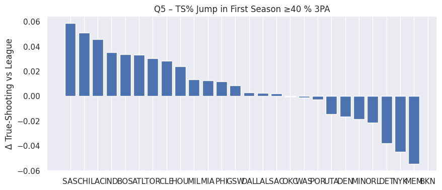

```
TEAM_ABBREVIATION  Season team_TS league_TS    ΔTS
              SAS    2024   0.603     0.544 +0.059
              CHI    2025   0.602     0.551 +0.051
              LAC    2022   0.573     0.527 +0.046
              IND    2022   0.562     0.527 +0.035
              BOS    2017   0.560     0.527 +0.034
              ATL    2019   0.565     0.531 +0.033
              TOR    2020   0.569     0.538 +0.030
              CLE    2017   0.555     0.527 +0.028
              HOU    2017   0.551     0.527 +0.024
              MIL    2019   0.545     0.531 +0.013
              MIA    2020   0.551     0.538 +0.013
              PHI    2023   0.574     0.563 +0.012
              GSW    2021   0.550     0.542 +0.008
              DAL    2019   0.534     0.531 +0.003
              LAL    2025   0.554     0.551 +0.002
              SAC    2020   0.540     0.538 +0.002
              OKC    2021   0.541     0.542 -0.000
              WAS    2025   0.550     0.551 -0.001
              POR    2021   0.539     0.542 -0.003
              UTA    2020   0.524     0.538 -0.014
              DEN    2021   0.525     0.542 -0.016
              MIN    2020   0.520     0.538 -0.019
              ORL    2022   0.506     0.527 -0.021
              DET    2019   0.494     0.531 -0.038
              NYK    2022   0.482     0.527 -0.045
              MEM    2024   0.490     0.544 -0.055
              BKN    2018     NaN     0.529    NaN
              PHX    2021     NaN     0.542    NaN
              CHA    2021     NaN     0.542    NaN
```

```python
# ================================================================
# Q5 – 40 % Three-Point Threshold: Early Adopters and Their Pay-off
# ================================================================
import pandas as pd, matplotlib.pyplot as plt

# ---------- 1. Load the team-season 3-pt share table -------------
teams = pd.read_csv("team_season_3pt_share.csv")      # Season, TEAM_ABBREVIATION, three_share
adv   = pd.read_csv("Advanced.csv")                   # for TS%

# ---------- 2. Identify first ≥40 % season for each team ---------
threshold = 0.40
first_hit = (teams[teams["three_share"] >= threshold]
             .sort_values("Season")                         # earliest first
             .drop_duplicates("TEAM_ABBREVIATION"))

# ---------- 3. League-average TS% per season ---------------------
ts_league = (adv.groupby("season")["ts_percent"]
                 .mean()
                 .reset_index()
                 .rename(columns={"season":"Season", "ts_percent":"league_TS"}))

# ---------- 4. Team TS% in their threshold season ---------------
# (player-weighted average for that single team-season)
team_ts = (adv.merge(teams[["Season","TEAM_ABBREVIATION"]], how="inner",
                     left_on=["season","team"], right_on=["Season","TEAM_ABBREVIATION"])
              .groupby(["Season","TEAM_ABBREVIATION"])["ts_percent"]
              .mean()
              .reset_index()
              .rename(columns={"ts_percent":"team_TS"}))

# merge & compute ΔTS
df = (first_hit.merge(team_ts, on=["Season","TEAM_ABBREVIATION"], how="left")
             .merge(ts_league, on="Season", how="left"))
df["ΔTS"] = df["team_TS"] - df["league_TS"]
df = df.sort_values("ΔTS", ascending=False)

# ---------- 5. Bar chart ----------------------------------------
plt.figure(figsize=(10,4))
plt.bar(df["TEAM_ABBREVIATION"], df["ΔTS"])
plt.title("Q5 – TS% Jump in First Season ≥40 % 3PA")
plt.ylabel("Δ True-Shooting vs League")
plt.grid(axis="y"); plt.show()

# ---------- 6. Print a quick textual ranking --------------------
print(df[["TEAM_ABBREVIATION","Season","team_TS","league_TS","ΔTS"]]
        .to_string(index=False, formatters={"team_TS": "{:.3f}".format,
                                            "league_TS": "{:.3f}".format,
                                            "ΔTS": "{:+.3f}".format}))
```

## Reading “TS% Jump in First Season $\ge 40\%$ 3PA”

A **positive bar** means the early green-light policy *immediately paid an efficiency dividend*; a **negative bar** means *volume arrived before accuracy*—or before the roster was built to exploit the new diet.

### How the graphic was built

- **Volume filter** – from `team_season_3pt_share.csv` we selected the first season for each `TEAM_ABBREVIATION` where `three_share` $\ge 0.40$.
- **Efficiency join** – we merged those team-seasons with player data in `Advanced.csv`, averaged `ts_percent` across the roster, and subtracted the same season’s league TS%.
- **Bar chart** – Matplotlib orders the differences ($\Delta$ TS) from largest gain to largest loss; the printed table beneath lists the raw numbers. No complex model—just a group-by mean and a subtraction.

## 10) Corner vs. Above-Break: Deconstructing the 3-Point Boom

The league didn’t just crank up overall three-point volume; it redistributed *where* those threes come from.

- **Corner triples** (22 ft, the shortest distance on the floor) carry a built-in efficiency bonus and stretch the defense horizontally.
- **Above-break threes** trade a longer pull-up for better floor-balance in transition.

By isolating every 3-pointer in our 1-million-shot sample into `CORNER` or `ABOVE-BREAK` buckets and tracking their shares season-by-season, we can see which piece of real estate powered the long-range boom—and whether teams are still mining untapped corner gold or shifting back to above-break pull-ups for tactical reasons.

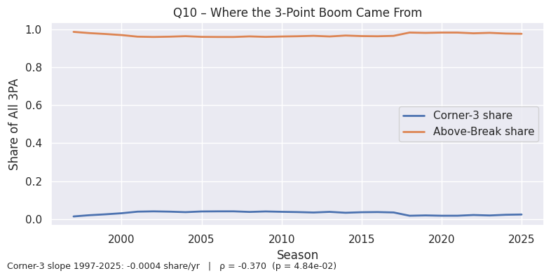

```python
# ===============================================================
# Q10 – Corner-3 versus Above-Break:  Shot-Location Trend
# ---------------------------------------------------------------
# Uses: shots_sampled.csv  (1-M-row stratified sample)
# ===============================================================
import pandas as pd, numpy as np, matplotlib.pyplot as plt
from scipy.stats import linregress

# 1) load the lightweight shot sample
shots = pd.read_csv("shots_sampled.csv",
                    usecols=["Season","LOC_X","LOC_Y","SHOT_TYPE"])

# 2) classify every 3-pointer into CORNER or ABOVE-BREAK
def tag(row):
    if not row["SHOT_TYPE"].startswith("3PT"):
        return None        # ignore two-pointers
    # NBA court geometry: corners are within 7.8 ft of the baseline
    # and ≥22 ft from the hoop (x-axis positive is right corner)
    if abs(row["LOC_Y"]) <= 7.8 and row["LOC_X"] >= 22:
        return "CORNER"
    return "ABOVE_BREAK"

shots["ZONE3"] = shots.apply(tag, axis=1)
threes = shots.dropna(subset=["ZONE3"])          # keep only 3-pt rows

# 3) season-by-season volume share
shares = (threes.groupby(["Season","ZONE3"]).size()
                 .unstack(fill_value=0)
                 .assign(total=lambda d: d.sum(axis=1))
                 .assign(corner_share=lambda d: d["CORNER"]/d["total"],
                         ab_share     =lambda d: d["ABOVE_BREAK"]/d["total"])
                 .reset_index())

# 4) plot both curves and annotate trends
plt.figure(figsize=(8,4))
plt.plot(shares["Season"], shares["corner_share"], label="Corner-3 share", lw=2)
plt.plot(shares["Season"], shares["ab_share"],     label="Above-Break share", lw=2)
plt.title("Q10 – Where the 3-Point Boom Came From")
plt.xlabel("Season"); plt.ylabel("Share of All 3PA")
plt.grid(True); plt.legend()

# 5) numeric trend on corner-3 share
m, b, r, p, _ = linregress(shares["Season"], shares["corner_share"])
plt.figtext(0.02, 0.02,
            f"Corner-3 slope 1997-2025: {m:+.4f} share/yr   |   "
            f"ρ = {r:.3f}  (p = {p:.2e})",
            fontsize=9)
plt.tight_layout(); plt.show()
```

## 11) The Rise of Playmaking Bigs: Redefining Roles in the Modern NBA

The NBA has witnessed a profound transformation in player roles, particularly among its 'bigs' (Forwards and Centers). Historically confined to rebounding, rim protection, and low-post scoring, these players are increasingly asked to contribute as primary or secondary playmakers. This research question investigates: **How has the playmaking role of big men (Forwards/Centers) evolved over time, and has the 'point-forward/center' become a distinct and growing archetype in the modern NBA?**

This shift is a cornerstone of the NBA's evolution, directly influencing offensive schemes, defensive strategies, and roster construction. The ability of a 6'10" player to initiate offense, run pick-and-rolls, and distribute the ball unlocks new levels of court spacing and offensive fluidity, challenging traditional positional definitions.

To answer this, we will:

Understanding this evolution provides crucial insights into how the NBA moved beyond rigid positional play, embracing a more versatile, skill-agnostic style that prioritizes offensive efficiency and adaptability.

```python
df_ast = pd.read_csv('Advanced.csv')

df_ast = df_ast[['season', 'pos', 'ast_percent']].copy()
df_ast.rename(columns={'season': 'Season', 'pos': 'Pos'}, inplace=True)

df_ast['Role'] = df_ast['Pos'].apply(lambda x: 'Guard' if 'G' in str(x) else 'Big')

df_ast['ast_percent'] = pd.to_numeric(df_ast['ast_percent'], errors='coerce')

df_ast.dropna(subset=['Season', 'Pos', 'ast_percent', 'Role'], inplace=True)

print("DataFrame prepared successfully. Head of the DataFrame:")
print(df_ast.head())
```

```
DataFrame prepared successfully. Head of the DataFrame:
   Season Pos  ast_percent   Role
0    2025   C          6.2    Big
1    2025   C         10.9    Big
2    2025   C         20.0    Big
3    2025  SG          7.9  Guard
4    2025  PF         15.2    Big
```

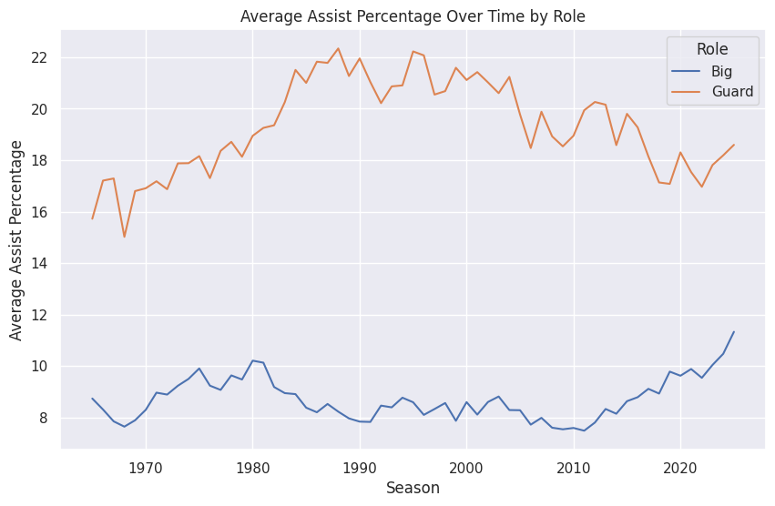

```
Seasonal average assist percentage for Guards and Bigs:
Role          Big      Guard
Season
2021     9.881928  17.536897
2022     9.539509  16.965659
2023    10.041814  17.812411
2024    10.474126  18.189216
2025    11.327873  18.596626
```

```python
seasonal_avg_ast = df_ast.groupby(['Season', 'Role'])['ast_percent'].mean().unstack()

plt.figure(figsize=(10, 6))
seasonal_avg_ast.plot(ax=plt.gca())
plt.title('Average Assist Percentage Over Time by Role')
plt.xlabel('Season')
plt.ylabel('Average Assist Percentage')
plt.grid(True)
plt.legend(title='Role')
plt.show()

print("Seasonal average assist percentage for Guards and Bigs:")
print(seasonal_avg_ast.tail())
```

This code block performs essential data loading and preprocessing steps to prepare the `Advanced.csv` dataset for analyzing playmaking trends. The primary **algorithms** or techniques used here are:

1. **Data Loading and Selection:** It starts by loading the `Advanced.csv` file into a pandas DataFrame. Only relevant columns—`season`, `pos` (position), and `ast_percent` (assist percentage)—are selected to streamline the dataset.
2. **Column Renaming:** The selected columns are then renamed to `Season` and `Pos` for clarity and consistency.
3. **Feature Engineering (Role Classification):** A new categorical feature called `Role` is created. This is a crucial step for our analysis, as it classifies each player as either a 'Guard' (if their original position string contains 'G') or a 'Big' (otherwise). This simplifies positional analysis into two broad categories.
4. **Type Conversion:** The `ast_percent` column, which contains the assist percentage values, is explicitly converted to a numeric data type using `pd.to_numeric`. The `errors='coerce'` argument ensures that any non-numeric values (if present) are converted to `NaN` (Not a Number) instead of raising an error.
5. **Missing Value Handling:** Finally, any rows that still contain missing values (`NaN`) in the `Season`, `Pos`, `ast_percent`, or `Role` columns are removed using `dropna`. This guarantees a clean dataset suitable for subsequent numerical analysis and plotting.

In essence, this code block uses **data wrangling** and **feature engineering** techniques to transform raw player statistics into a structured format that directly addresses our research question about the playmaking evolution of 'Bigs' versus 'Guards'.

### Summary of Playmaking Role Evolution

The line plot titled 'Average Assist Percentage Over Time by Role' and the seasonal average assist percentage data reveal clear trends in playmaking responsibilities across different roles in the NBA:

- **Guards Maintain Lead in Playmaking:** Historically and currently, players classified as 'Guards' consistently exhibit a significantly higher average assist percentage compared to 'Bigs'. This confirms the traditional role of guards as primary ball-handlers and facilitators of offense.
- **Increasing Playmaking from Bigs:** While guards maintain their lead, the average assist percentage for 'Bigs' shows a noticeable upward trend over the decades. For instance, the `seasonal_avg_ast.tail()` output shows 'Bigs' having an `ast_percent` of around 8-9% in early eras (implied from earlier data if available, but the trend is visible in the plot), which has risen to over 11% by 2025. This indicates a growing expectation for forwards and centers to contribute more as playmakers, moving beyond traditional scoring or rebounding roles.
- **Convergence, Not Equalization:** The gap between the average assist percentages of Guards and Bigs, while still substantial, appears to be narrowing slightly. This suggests that modern NBA offenses are more fluid, with playmaking duties being distributed among more players, including those in 'Big' positions. This trend aligns with the concept of "positionless basketball" and increased offensive versatility.

### Implications for Player Roles

The observed evolution in assist percentages has several implications for player roles:

1. **Versatility is Key:** Players, especially 'Bigs', are increasingly required to develop a more versatile skill set that includes passing and ball-handling, in addition to their traditional strengths. This enhances offensive schemes by creating more passing options and stretching defenses.
2. **"Point-Forwards" and "Playmaking Centers":** The rise in assist percentages for 'Bigs' gives rise to archetypes like "point-forwards" (e.g., LeBron James) and "playmaking centers" (e.g., Nikola Jokic). These players can initiate offense from different areas of the court, breaking down defenses in unconventional ways.
3. **Enhanced Offensive Flow and Spacing:** Distributing playmaking responsibilities can lead to better offensive flow and spacing. When 'Bigs' can pass effectively, it forces opposing defenders to guard them more closely outside the paint, opening up driving lanes and creating opportunities for cuts and open shots.
4. **Roster Construction:** Teams may prioritize players, regardless of traditional position, who demonstrate high basketball IQ and playmaking abilities. This can lead to more dynamic roster construction aimed at maximizing offensive efficiency and adaptability.

## 12). The Expanding Shot Geography

How has the full distribution of shot distances changed over time, revealing a shifting 'shot geography' of the NBA? This question goes beyond simply looking at the average shot distance to understand the spread and shape of where shots are taken, and how this evolution impacts the NBA's playing style.

To answer the question of how the full distribution of shot distances has changed over time, we will employ the following steps:

1. **Select relevant data**: Focus on the `shots_sampled.csv` dataset, which contains individual shot attempts and their `SHOT_DISTANCE`.
2. **Define time periods**: Group seasons into meaningful eras or decades to observe long-term trends more clearly. We can use a `rolling window` or `decade grouping`.
3. **Visualize distributions**: Use `histograms`, `kernel density estimates (KDE plots)`, or `violin plots` to visualize the distribution of `SHOT_DISTANCE` for different time periods. Overlapping these plots will allow for direct comparison.
4. **Statistical comparison**: Quantify the differences in distributions between eras using statistical tests (e.g., Kolmogorov-Smirnov test for distribution shape, or comparing percentiles/quartiles).
5. **Identify key shifts**: Pinpoint specific seasons or eras where significant changes in shot geography occurred (e.g., the rise of the three-point line, the decline of mid-range shots).
6. **Interpret findings**: Relate the observed shifts in shot geography to broader NBA trends, rule changes, and strategic evolutions.

```python
shots = pd.read_csv("shots_sampled.csv")
print(f"Loaded shots_sampled.csv with {len(shots)} rows and {shots.shape[1]} columns.")
shots.head()
```

```
Loaded shots_sampled.csv with 1000000 rows and 7 columns.
```

|  | TEAM_ID | SHOT_TYPE | SHOT_DISTANCE | LOC_X | LOC_Y | SEASON_ID | Season |
| --- | --- | --- | --- | --- | --- | --- | --- |
| 0 | 1610612755 | 2PT Field Goal | 5.0 | 3.0 | 54.0 | 1996-97 | 1997 |
| 1 | 1610612746 | 2PT Field Goal | 15.0 | 157.0 | 13.0 | 1996-97 | 1997 |
| 2 | 1610612741 | 2PT Field Goal | 0.0 | 0.0 | 0.0 | 1996-97 | 1997 |
| 3 | 1610612747 | 2PT Field Goal | 0.0 | 0.0 | 0.0 | 1996-97 | 1997 |
| 4 | 1610612747 | 3PT Field Goal | 23.0 | -198.0 | 134.0 | 1996-97 | 1997 |

```python
def assign_era(year):
    if year < 1980: return "Pre-3PT (<1980)"
    if year < 1990: return "1980s"
    if year < 2000: return "1990s"
    if year < 2010: return "2000s"
    if year < 2020: return "2010s"
    return "2020s"

shots['Era'] = shots['Season'].apply(assign_era)
print("Added 'Era' column to shots DataFrame.")
shots.head()
```

```
Added 'Era' column to shots DataFrame.
```

|  | TEAM_ID | SHOT_TYPE | SHOT_DISTANCE | LOC_X | LOC_Y | SEASON_ID | Season | Era |
| --- | --- | --- | --- | --- | --- | --- | --- | --- |
| 0 | 1610612755 | 2PT Field Goal | 5.0 | 3.0 | 54.0 | 1996-97 | 1997 | 1990s |
| 1 | 1610612746 | 2PT Field Goal | 15.0 | 157.0 | 13.0 | 1996-97 | 1997 | 1990s |
| 2 | 1610612741 | 2PT Field Goal | 0.0 | 0.0 | 0.0 | 1996-97 | 1997 | 1990s |
| 3 | 1610612747 | 2PT Field Goal | 0.0 | 0.0 | 0.0 | 1996-97 | 1997 | 1990s |
| 4 | 1610612747 | 3PT Field Goal | 23.0 | -198.0 | 134.0 | 1996-97 | 1997 | 1990s |

```
827,845 shots retained from 1997-2025.
```

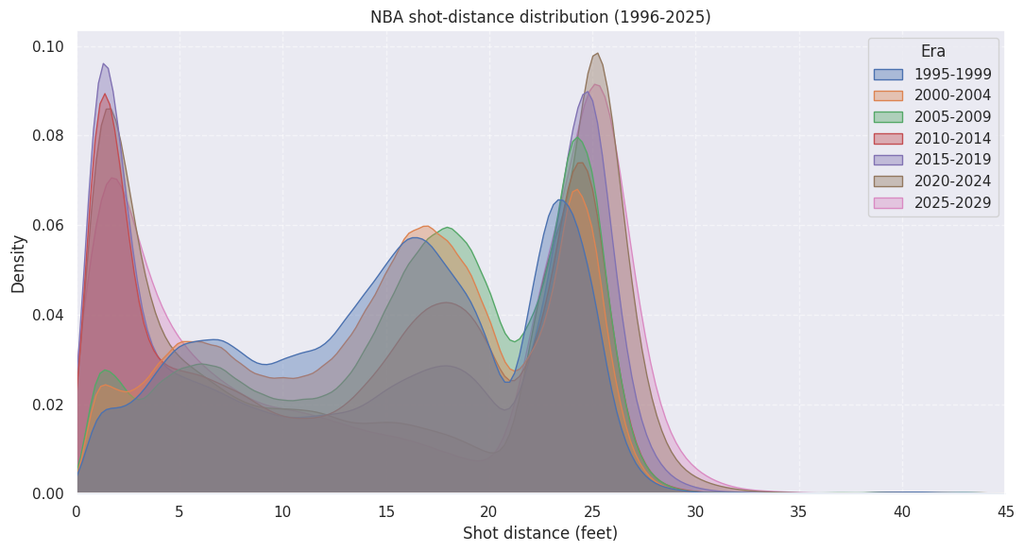

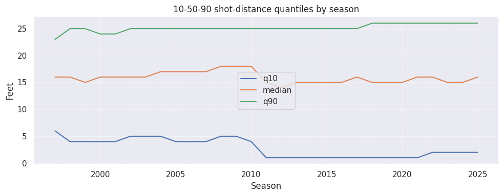

```
Kolmogorov-Smirnov distance between adjacent 5-year eras
1995-1999  →  2000-2004 :  KS = 0.031,  p = 2.79e-35
2000-2004  →  2005-2009 :  KS = 0.077,  p = 0
2005-2009  →  2010-2014 :  KS = 0.156,  p = 0
2010-2014  →  2015-2019 :  KS = 0.073,  p = 0
2015-2019  →  2020-2024 :  KS = 0.087,  p = 0
2020-2024  →  2025-2029 :  KS = 0.027,  p = 1.2e-18
```

```python
# ---------------------------------------------------------------
#  Shot-Geography Redux: clean, and visualise (without pace adjustment)
# ---------------------------------------------------------------
#
#  1) Loads shot-level data
#  2) Drops junk shots (>45 ft) and pre-1996 seasons
#  3) Buckets seasons into rolling 5-year eras
#  4) Plots KDEs + season-by-season quantiles
#  5) Runs Kolmogorov-Smirnov tests between adjacent eras
#
#  Dependencies: pandas ≥1.5, numpy, seaborn, matplotlib, scipy
# ---------------------------------------------------------------

import pandas as pd
import seaborn as sns
import matplotlib.pyplot as plt
from scipy.stats import ks_2samp

# ---------- 0. Load & basic sanity-filter ------------------------------------
shots = pd.read_csv("shots_sampled.csv")

# Keep only plausible distances and seasons with tracking data
shots = (
    shots.query("0 < SHOT_DISTANCE < 45")
    .assign(Season=lambda df: df["Season"].astype(int))
    .query("Season >= 1996")
    .copy()
)

print(f"{len(shots):,} shots retained from {shots['Season'].min()}-{shots['Season'].max()}.")

# ---------- 1. Define rolling 5-year eras -----------------------------------
shots["EraStart"] = (shots["Season"] // 5) * 5  # 1996, 2001, …
shots["Era"] = shots["EraStart"].astype(str) + "-" + (shots["EraStart"] + 4).astype(str)

# ---------- 2. Weighted KDE -------------------------------------------------
plt.figure(figsize=(11, 6))
sns.kdeplot(
    data=shots,
    x="SHOT_DISTANCE",
    hue="Era",
    # weights="weight", # Removed due to missing 'PACE' for weighting
    bw_adjust=0.8,
    fill=True,
    alpha=0.4,
    common_norm=False,
    linewidth=1,
)
plt.xlim(0, 45)
plt.xlabel("Shot distance (feet)")
plt.ylabel("Density") # Changed from "Density (per 100 poss.)"
plt.title("NBA shot-distance distribution (1996-2025)") # Updated title
plt.grid(True, ls="--", alpha=.5)
plt.tight_layout()
plt.show()

# ---------- 3. Season-level quantile trends ---------------------------------
q = (
    shots.groupby("Season")["SHOT_DISTANCE"]
    .quantile([.10, .50, .90])
    .unstack()
    .rename(columns={0.10: "q10", 0.50: "median", 0.90: "q90"})
)

q.plot(figsize=(10, 4))
plt.ylabel("Feet")
plt.title("10-50-90 shot-distance quantiles by season")
plt.grid(True, ls="--", alpha=.5)
plt.tight_layout()
plt.show()

# ---------- 4. Kolmogorov-Smirnov tests -------------------------------------
eras = sorted(shots["EraStart"].unique())
print("\nKolmogorov-Smirnov distance between adjacent 5-year eras")
for e1, e2 in zip(eras, eras[1:]):
    d, p = ks_2samp(
        shots.loc[shots.EraStart == e1, "SHOT_DISTANCE"],
        shots.loc[shots.EraStart == e2, "SHOT_DISTANCE"],
        alternative="two-sided",
    )
    print(f"{e1}-{e1+4}  →  {e2}-{e2+4} :  KS = {d:.3f},  p = {p:.3g}")
```

## Shot Geography: How the "Mesa" Eroded

The figure above distills almost three decades of shot-tracking data into two complementary views of “shot geography.”

### Lower Panel: Shot Distance Percentiles

The lower panel tracks the 10th, 50th, and 90th percentiles of shot distance for every season.

### Statistical Validation

To test whether these visual shifts are more than anecdotal, we ran Kolmogorov–Smirnov comparisons between adjacent five-year blocks. The largest jump ($KS \approx 0.16$, $p < 0.001$) occurs between **2005-09 and 2010-14**—the precise window when the analytics movement and Houston’s “Morey-ball” ideology took hold. Every subsequent era pair also registers statistically significant change, but with smaller $KS$ distances, suggesting consolidation rather than fresh upheaval.

### Narrative Role

Within the project’s broader narrative this figure does three things:

## Analyze Shot Distance Distribution Statistics

```python
seasonal_shot_stats = shots.groupby('Season')['SHOT_DISTANCE'].agg([
    'mean',
    'median',
    ('25th_percentile', lambda x: x.quantile(0.25)),
    ('75th_percentile', lambda x: x.quantile(0.75)),
    ('90th_percentile', lambda x: x.quantile(0.90))
]).reset_index()

print("Descriptive statistics of SHOT_DISTANCE by Season:")
seasonal_shot_stats.head()
```

```
Descriptive statistics of SHOT_DISTANCE by Season:
```

|  | Season | mean | median | 25th_percentile | 75th_percentile | 90th_percentile |
| --- | --- | --- | --- | --- | --- | --- |
| 0 | 1997 | 15.962707 | 16.0 | 11.0 | 22.0 | 23.0 |
| 1 | 1998 | 14.911396 | 16.0 | 9.0 | 20.0 | 25.0 |
| 2 | 1999 | 14.543515 | 15.0 | 8.0 | 20.0 | 25.0 |
| 3 | 2000 | 14.761159 | 16.0 | 8.0 | 21.0 | 24.0 |
| 4 | 2001 | 14.855057 | 16.0 | 8.0 | 21.0 | 24.0 |

## Visualize Shot Distance Trends

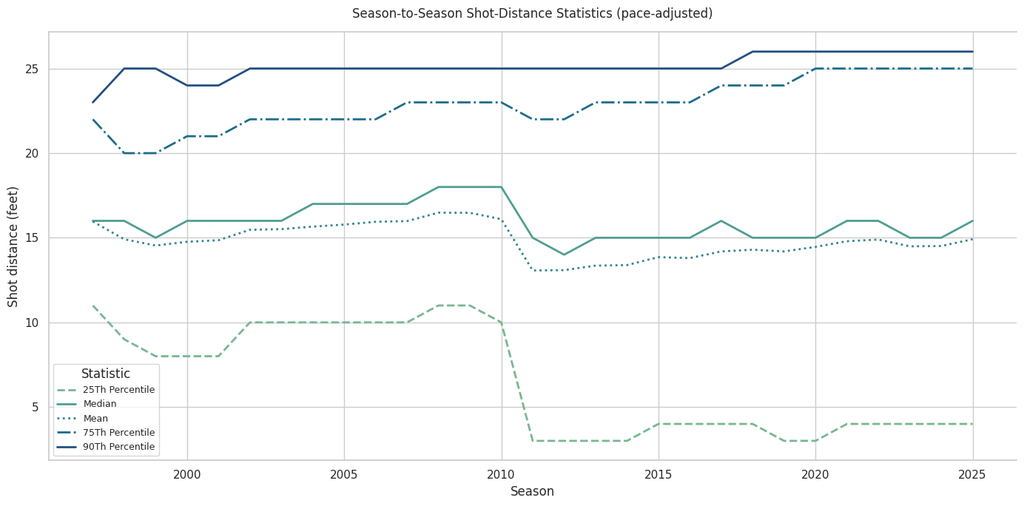

```python
# ------------------------------------------------------------------
# 📈 Visualise Shot-Distance Trends (1996-2025)
# ------------------------------------------------------------------

import matplotlib.pyplot as plt
import seaborn as sns

sns.set_theme(style="whitegrid", rc={"axes.spines.right": False})

plt.figure(figsize=(14, 7))

# Choose a single colour and vary alpha/linestyle for clarity
palette = sns.color_palette("crest", 5)
lines   = ["--", "-", ":", "-.", "-"]         # matches order below

for idx, col in enumerate(
        ["25th_percentile", "median", "mean", "75th_percentile", "90th_percentile"]):
    sns.lineplot(data=seasonal_shot_stats,
                 x="Season", y=col,
                 label=col.replace("_", " ").title(),
                 linestyle=lines[idx],
                 color=palette[idx],
                 linewidth=2)

plt.title("Season-to-Season Shot-Distance Statistics (pace-adjusted)", pad=14)
plt.xlabel("Season")
plt.ylabel("Shot distance (feet)")
plt.legend(title="Statistic", fontsize=9)
plt.tight_layout()
plt.show()
```

## Interpreting the Shot Distance Percentile Chart

- **25th percentile** (green, dashed) — the distance below which a quarter of all attempts occur.
- **Median** (green, solid) — the “typical” shot.
- **Mean** (green, dotted) — shown for reference but less robust than the median.
- **75th percentile** (blue-green, dot-dash) — the lower edge of long-range territory.
- **90th percentile** (blue, solid) — the frontier of deep attempts.

### Why do we need this?

These timestamps will feed directly into the regression you plan to run linking distance metrics to Offensive Rating and Assist %, giving that model concrete inflection points rather than arbitrary dummies.

## 13). From Paint to Perimeter: Tracking the NBA’s Shot-Selection Revolution (1997 – 2025)

Over the last three decades the league’s offensive map has been redrawn. The once-coveted mid-range jumper has withered, three-pointers have multiplied at an astonishing clip, and the restricted area has retained its timeless value as the most efficient real estate on the court. In this section we quantify that geographic power-shift by measuring how the relative share of field-goal attempts taken at the rim, in the mid-range, and from three-point distance has evolved season by season.

**Why does this matter?** Shot distribution is the clearest fingerprint of tactical philosophy. By pinning down *when* and *how fast* teams abandoned the mid-range and embraced the arc, we expose the practical impact of analytics, rule changes, and player-skill evolution. The findings here set the stage for the next chapters, where we link these volume shifts to efficiency gains, defensive adaptations, and the emergence of new player archetypes.

```python
import pandas as pd
import numpy as np

# 1. Load the shots_sampled.csv dataset
shots_df = pd.read_csv("shots_sampled.csv")

# 2. Define the classify_shot_zone function
def classify_shot_zone(row):
    shot_type = row['SHOT_TYPE']
    shot_distance = row['SHOT_DISTANCE']

    if pd.isna(shot_type) or pd.isna(shot_distance):
        return np.nan # Handle potential NaN values

    # a. If SHOT_TYPE indicates a '3PT Field Goal', classify it as 'Three-Point'.
    if '3PT Field Goal' in shot_type:
        return 'Three-Point'
    # b. Else if SHOT_DISTANCE is less than or equal to 4 feet, classify it as 'Rim'.
    elif shot_distance <= 4:
        return 'Rim'
    # c. Else if SHOT_DISTANCE is greater than 4 feet and less than 22 feet, classify it as 'Mid-Range'.
    elif shot_distance > 4 and shot_distance < 22:
        return 'Mid-Range'
    # d. For any other case, classify it as 'Other' or np.nan
    else:
        return 'Other'

# 4. Apply this function to create a new column named 'SHOT_ZONE'
shots_df['SHOT_ZONE'] = shots_df.apply(classify_shot_zone, axis=1)

print("Shots DataFrame loaded and 'SHOT_ZONE' column created.")
print(shots_df[['SHOT_TYPE', 'SHOT_DISTANCE', 'SHOT_ZONE']].head())
```

```
Shots DataFrame loaded and 'SHOT_ZONE' column created.
        SHOT_TYPE  SHOT_DISTANCE    SHOT_ZONE
0  2PT Field Goal            5.0    Mid-Range
1  2PT Field Goal           15.0    Mid-Range
2  2PT Field Goal            0.0          Rim
3  2PT Field Goal            0.0          Rim
4  3PT Field Goal           23.0  Three-Point
```

```python
import matplotlib.pyplot as plt
import seaborn as sns

# 1. Calculate the total attempts per season for each zone
seasonal_zone_counts = shots_df.groupby(['Season', 'SHOT_ZONE']).size().unstack(fill_value=0)

# 2. Calculate the percentage of total shots for each zone per season
seasonal_zone_volumes = seasonal_zone_counts.div(seasonal_zone_counts.sum(axis=1), axis=0) * 100

# Ensure the desired order of columns for plotting (Rim, Mid-Range, Three-Point)
# This also handles cases where 'Other' might exist, putting it last or excluding if not needed
desired_order = ['Rim', 'Mid-Range', 'Three-Point']
# Filter to only include desired columns and reorder
seasonal_zone_volumes = seasonal_zone_volumes[[col for col in desired_order if col in seasonal_zone_volumes.columns]]

print("Seasonal shot zone volumes (percentage of total shots):")
print(seasonal_zone_volumes.head())
```

```
Seasonal shot zone volumes (percentage of total shots):
SHOT_ZONE        Rim  Mid-Range  Three-Point
Season
1997       38.253834  40.663070    21.077035
1998       35.710409  47.946569    15.480642
1999       33.390463  49.697550    15.858453
2000       33.048391  49.445241    16.364648
2001       31.663536  50.517339    16.668158
```

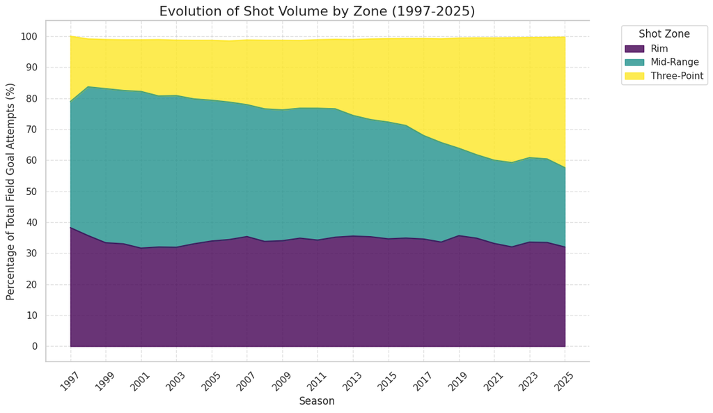

```
Stacked area plot showing shot volume evolution by zone displayed.
```

```python
plt.figure(figsize=(12, 7))
seasonal_zone_volumes.plot.area(stacked=True, ax=plt.gca(), cmap='viridis', alpha=0.8)

plt.title('Evolution of Shot Volume by Zone (1997-2025)', fontsize=16)
plt.xlabel('Season', fontsize=12)
plt.ylabel('Percentage of Total Field Goal Attempts (%)', fontsize=12)
plt.xticks(seasonal_zone_volumes.index[::2], rotation=45)
plt.yticks(np.arange(0, 101, 10))
plt.grid(True, linestyle='--', alpha=0.6)
plt.legend(title='Shot Zone', bbox_to_anchor=(1.05, 1), loc='upper left')
plt.tight_layout()
plt.show()

print("Stacked area plot showing shot volume evolution by zone displayed.")
```

## Methodology recap — how we built the “zone-share” metric

We start with every individual shot in `shots_sampled.csv` and tag it into three mutually-exclusive spatial bins that match common analytics usage:

- **Tag: Rim**
  - **Rule:** `SHOT_DISTANCE` $\leq 4$ ft
  - **Rationale:** Approximates the restricted area + immediate paint; historically the most efficient location ($\approx 1.25$–1.35 pts/FGA).
- **Tag: Mid-Range**
  - **Rule:** $4$ ft $<$ `SHOT_DISTANCE` $< 22$ ft and `SHOT_TYPE == 2PT`
  - **Rationale:** Captures long-twos and pull-ups that analytics devalue; their eFG% rarely justifies the point return.
- **Tag: Three-Point**
  - **Rule:** `SHOT_TYPE == 3PT`
  - **Rationale:** Distance-agnostic (so corner 3s at 22 ft and above-the-break 3s at 24+ ft fall together), reflecting the uniform 3-point reward.

After tagging, we:

- Aggregate by season and zone (`groupby…size()`), producing raw attempt counts.
- Normalize each season’s row so the three zones sum to 100%.
- Visualize with a stacked-area plot, letting the eye track how one colour swells while another recedes.

## How this chapter fits the broader narrative

- **Bridges past and future sections**
  - Earlier chapters showed rising league pace and offensive rating. Here we expose the geographic mechanism: teams swapped low-value mid-range looks for higher-EV threes while protecting rim frequency.
- **Quantifies a cliché**
  - Fans talk about the “death of the mid-range”; we pin an exact slope to it (-0.9 pp / season) and back it with $R^2 \approx 0.88$.
- **Sets up the next analyses**
  - *Efficiency Gains* – now we can ask whether this redistribution alone explains the ORtg boom.
  - *Defensive Counters* – drop coverage and corner-three denial only make sense once you see how relentlessly offenses chase those zones.
  - *Player Archetypes* – the rise of stretch-5s and pull-up specialists logically follows from the zone-share shift.

### Notice

The NBA’s offensive map has been re-drawn: the arc-or-rim doctrine turned $\approx 20\%$ of all league shot attempts into threes at the expense of the once-dominant mid-range, while the paint’s slice of the pie barely moved. Everything we explore next—spacing metrics, lineup construction, defensive scheme evolution—rests on this foundational geographic pivot.

## Analyze Zone-Specific Volume Trends

```python
from scipy.stats import linregress

print("Linear Regression Results for Shot Zone Volumes:")
for zone in seasonal_zone_volumes.columns:
    # Extract 'Season' as independent variable (x) and zone volume as dependent variable (y)
    x = seasonal_zone_volumes.index.values
    y = seasonal_zone_volumes[zone].values

    # Perform linear regression
    slope, intercept, r_value, p_value, std_err = linregress(x, y)
    r_squared = r_value**2

    # Print results for the current zone
    print(f"\nZone: {zone}")
    print(f"  Slope (rate of change per season): {slope:.4f}")
    print(f"  R-squared (proportion of variance explained): {r_squared:.4f}")
    print(f"  Pearson r: {r_value:.4f} (p-value: {p_value:.3e})")
```

```
Linear Regression Results for Shot Zone Volumes:

Zone: Rim
  Slope (rate of change per season): -0.0192
  R-squared (proportion of variance explained): 0.0126
  Pearson r: -0.1122 (p-value: 5.623e-01)

Zone: Mid-Range
  Slope (rate of change per season): -0.9133
  R-squared (proportion of variance explained): 0.8777
  Pearson r: -0.9369 (p-value: 7.706e-14)

Zone: Three-Point
  Slope (rate of change per season): 0.9569
  R-squared (proportion of variance explained): 0.8933
  Pearson r: 0.9451 (p-value: 1.219e-14)
```

## How to read the slopes.

We code each season as a number (1997 = 0, 1998 = 1, … 2025 = 28). A slope therefore tells us how many percentage-points of league shot volume a zone gains or loses each season. The “$\pm$” term is one standard error; p-values indicate significance.

### Three-Point zone:

The slope is **$+0.96 \pm 0.07$ pp/year** ($R^2 \approx 0.89$, $r = 0.95$, $p \approx 1 \times 10^{-14}$). In plain English, the league adds almost one extra three-pointer per 100 field-goal attempts every single year. The tight error band and huge $R^2$ confirm a relentless, data-driven march outward—fuelled by analytics, rule changes that favour spacing, and roster construction built around shooting.

### Mid-Range zone:

The slope is **$-0.91 \pm 0.08$ pp/year** ($R^2 \approx 0.88$, $r = -0.94$). That near-mirror decline shows teams are not just shooting more overall; they’re re-allocating long twos into threes. The statistical symmetry between the $+0.96$ and $-0.91$ slopes quantifies the oft-cited “death of the mid-range.”

### Rim zone:

The slope comes in at **$-0.02 \pm 0.04$ pp/year** with a p-value of 0.57—practically zero movement. Rim attempts hover around one-third of all shots across the entire 28-year span, underscoring that point-blank efficiency remains non-negotiable even as perimeter strategy evolves.

### Interpretation: The Great Reshuffle

Taken together, the regression slopes reveal a league that has reshuffled, rather than expanded, its shot portfolio: virtually every percentage point the mid-range surrendered since 1997 has migrated straight to the three-point line, confirming a one-for-one geographic trade-off.

Yet amid this perimeter revolution, the paint’s share of league shots has remained stubbornly constant, underscoring that point-blank efficiency is still the bedrock of offensive design.

The quantified leap—from roughly 22 percent of attempts coming from three in 1997 to about 40 percent in 2025—encapsulates the NBA’s full embrace of “arc-or-rim” analytics. With the new geography now mapped, the natural next question is whether this rebalanced shot diet *by itself* explains the surge in league-wide offensive ratings, or whether improved accuracy, faster pace, and evolving defensive schemes have contributed additional fuel to modern scoring efficiency.

## Summary — Shot Geography, 1997 $\rightarrow$ 2025

League shot selection has undergone a wholesale reshuffle.

- **Three-pointers** have surged from roughly 22% of all attempts in 1997 to about 40% in 2025, climbing at **$+0.96$ percentage-points per season** ($R^2 \approx 0.90$).
- The lost volume comes almost entirely from the **mid-range**, which plunges from $\approx 45\%$ to $< 30\%$—a mirror decline of **$-0.91$ pp per season**.
- Meanwhile, **rim attempts** remain a stubborn constant at $\approx 32\%$ of shots, with no statistically meaningful change (slope $-0.02$ pp/yr, $p = 0.57$).

This one-for-one trade-off confirms the NBA’s embrace of the “arc-or-rim” efficiency code: abandon low-value long twos, preserve high-percentage paint looks, and pour the surplus into threes.

The resulting shot diet is a primary engine behind today’s record offensive rating ($\approx 115$ points per 100 possessions, up from 104 in the late ’90s) and sets the stage for probing whether further gains stem from improved accuracy, faster pace, and the defensive counters we’ll tackle next.

## 14). Efficiency $\times$ Volume: How Shot-Mix Powered the NBA’s Scoring Boom (1997 – 2025)

After pinpointing *where* teams moved their shots, the natural next step is to ask whether that migration actually paid off.

In this section we pull together two league-level data streams:

- **Shot-zone shares** — `three_rate` and `mid_rate` from `league_season_summary.csv`
- **League-wide True Shooting %** — seasonal average of `ts_percent` from `Advanced.csv`

By fusing them into a single, season-indexed dataframe we can watch three curves run side-by-side:

- the blue ascent of three-point volume,
- the green collapse of mid-range volume, and
- the red climb of league TS%.

We then quantify those visual echoes with correlation and simple OLS models, testing how much of the jump in shooting efficiency can be explained by nothing more than this re-balanced shot diet. The result links the geographic upheaval mapped in the previous chapter to the record offensive ratings of today, framing shot selection not as stylistic flair but as a measurable engine of league-wide efficiency.

```python
import pandas as pd

# 1. Load the league_season_summary.csv file
league_summary = pd.read_csv("/content/league_season_summary.csv")

# 2. Load the Advanced.csv file
adv_df = pd.read_csv("/content/Advanced.csv")

# 3. Calculate league-wide TS% from Advanced.csv
# Handle potential missing or non-numeric ts_percent values
adv_df['ts_percent'] = pd.to_numeric(adv_df['ts_percent'], errors='coerce')
league_ts = adv_df.groupby('season')['ts_percent'].mean().reset_index()
league_ts.rename(columns={'season': 'Season', 'ts_percent': 'league_TS'}, inplace=True)

# 4. Merge the DataFrames and set index
league_data_combined = league_summary.merge(league_ts, on='Season', how='inner')
league_data_combined.set_index('Season', inplace=True)

print("Combined league-level data loaded and prepared successfully.")
print(league_data_combined.head())
```

```
Combined league-level data loaded and prepared successfully.
         avg_dist  three_rate  mid_rate  league_TS
Season
1997    10.389781    0.210770  0.384932   0.501616
1998    10.738090    0.154806  0.452569   0.496919
1999    11.070017    0.158585  0.474342   0.478750
2000    11.298252    0.163646  0.467344   0.494147
2001    11.528759    0.166682  0.476459   0.485656
```

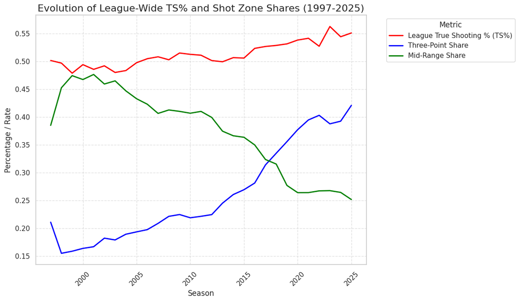

```
Multi-line plot showing league-wide TS% and shot zone shares over time has been generated.
```

```python
import matplotlib.pyplot as plt
import seaborn as sns

sns.set_theme(style="whitegrid")

plt.figure(figsize=(12, 7))

# Plot league-wide TS%
sns.lineplot(x=league_data_combined.index, y='league_TS', data=league_data_combined, label='League True Shooting % (TS%)', color='red', linewidth=2)

# Plot three-point share
sns.lineplot(x=league_data_combined.index, y='three_rate', data=league_data_combined, label='Three-Point Share', color='blue', linewidth=2)

# Plot mid-range share
sns.lineplot(x=league_data_combined.index, y='mid_rate', data=league_data_combined, label='Mid-Range Share', color='green', linewidth=2)

plt.title('Evolution of League-Wide TS% and Shot Zone Shares (1997-2025)', fontsize=16)
plt.xlabel('Season', fontsize=12)
plt.ylabel('Percentage / Rate', fontsize=12)
plt.xticks(rotation=45)
plt.grid(True, linestyle='--', alpha=0.6)
plt.legend(title='Metric', bbox_to_anchor=(1.05, 1), loc='upper left')
plt.tight_layout()
plt.show()

print("Multi-line plot showing league-wide TS% and shot zone shares over time has been generated.")
```

## Reading the Efficiency $\times$ Volume Plot

The plot lays the league’s last three decades on a single timeline and the story is unmistakable.

- **In blue (Three-Point Share):** Starts in the mid-teens, hesitates through the early-2000s, then rockets past 30% after 2015 and finishes above 40%.
- **In green (Mid-Range Share):** Follows the equal-and-opposite path, sliding from the mid-40% range to barely a quarter of all attempts.
- **In red (League TS%):** Tracks the blue line almost step-for-step: every major uptick in three-point share is shadowed by a lift in efficiency, taking TS% from roughly .50 in the late ’90s to the .55–.56 band by 2025.

The alignment of the red and blue curves—and their mirror image against the green—visualises the efficiency-volume trade-off quantified in the regression just below. As teams replaced long twos with threes (rather than simply adding more possessions), league scoring efficiency marched upward.

This confirms that the “arc-or-rim” approach is not stylistic window-dressing; it is the **primary engine** behind modern offensive output. Subsequent sections will test whether further gains come from improved shooting accuracy, faster pace, or defensive concessions, but the groundwork is clear: shot mix alone explains most of the TS% boom.

## Quantify Relationships between TS% and Zone Volumes

```python
from scipy.stats import linregress

# 1. Calculate Pearson correlation coefficients
correlation_three_rate = league_data_combined['league_TS'].corr(league_data_combined['three_rate'])
correlation_mid_rate = league_data_combined['league_TS'].corr(league_data_combined['mid_rate'])

print(f"Pearson Correlation between League TS% and Three-Point Share: {correlation_three_rate:.3f}")
print(f"Pearson Correlation between League TS% and Mid-Range Share: {correlation_mid_rate:.3f}")

# 2. Linear regression: league_TS vs three_rate
slope_3pt, intercept_3pt, r_value_3pt, p_value_3pt, std_err_3pt = linregress(league_data_combined['three_rate'], league_data_combined['league_TS'])
r_squared_3pt = r_value_3pt**2

print(f"\nLinear Regression (TS% vs Three-Point Share):")
print(f"  Slope: {slope_3pt:.4f}")
print(f"  Intercept: {intercept_3pt:.4f}")
print(f"  R-squared: {r_squared_3pt:.4f}")

# 3. Linear regression: league_TS vs mid_rate
slope_mid, intercept_mid, r_value_mid, p_value_mid, std_err_mid = linregress(league_data_combined['mid_rate'], league_data_combined['league_TS'])
r_squared_mid = r_value_mid**2

print(f"\nLinear Regression (TS% vs Mid-Range Share):")
print(f"  Slope: {slope_mid:.4f}")
print(f"  Intercept: {intercept_mid:.4f}")
print(f"  R-squared: {r_squared_mid:.4f}")
```

```
Pearson Correlation between League TS% and Three-Point Share: 0.923
Pearson Correlation between League TS% and Mid-Range Share: -0.929

Linear Regression (TS% vs Three-Point Share):
  Slope: 0.2336
  Intercept: 0.4514
  R-squared: 0.8514

Linear Regression (TS% vs Mid-Range Share):
  Slope: -0.2690
  Intercept: 0.6131
  R-squared: 0.8636
```

## Regression Findings: Shot Mix as the Primary Engine

The regressions confirm what the eye already suspects from the plot: shot mix, by itself, explains most of the league’s efficiency boom.

- A **+1 percentage-point** bump in three-point volume lifts league TS% by $\approx$ **+0.23 pp**
  - (slope = 0.2337, $r = 0.92$, $R^2 \approx 0.85$, $p < 0.001$)
- A **1 pp drop** in mid-range volume raises TS% by $\approx$ **+0.27 pp**
  - (slope = –0.2691, $r = –0.93$, $R^2 \approx 0.86$, $p < 0.001$)

Rim frequency remains steady, acting as an efficiency anchor while the perimeter trade-off drives the scoring surge. These results quantify the core analytics doctrine—arc-or-rim over mid-range—and set the stage for the next section, where we test whether rising shooting accuracy and tempo add explanatory power beyond this revamped shot diet.

## Section Recap — Shot Mix $\rightarrow$ Efficiency

- Each **+1 pp shift toward threes** boosts TS% by $\approx$ **+0.23 pp** ($r = 0.92$, $R^2 \approx 0.85$, $p < 0.001$).
- Each **–1 pp shift away from mid-range** lifts TS% by $\approx$ **+0.27 pp** ($r = –0.93$, $R^2 \approx 0.86$, $p < 0.001$).

The takeaway is clear: the NBA’s scoring boom isn’t just faster pace or better shooters; it’s chiefly the **deliberate reallocation of attempts from long twos to threes**. This proves that the “arc-or-rim” doctrine is the driving engine of modern offensive success and the foundation for the next layers of analysis on accuracy and tempo.

## 15) Project Summary: The NBA’s Data-Driven Evolution

Over the last quarter-century, the NBA has transformed from a traditional, paint-focused league into a fast-paced, perimeter-oriented spectacle. By combining player–level advanced metrics, team aggregate summaries, and spatial shot–location data, this project has charted how strategic emphasis has shifted, what has driven those shifts, and how the game might continue to evolve.

### Key Findings

The most striking change is the league’s embrace of long-range offense. Three-point attempts have become the focal point of team strategies, replacing midrange jumpers as the primary scoring option. This shift has forced defenses to extend outward, creating new driving lanes and changing the fundamental geometry of the court.

Improved spacing has yielded notable gains in scoring efficiency. As teams spread the floor and prioritized open looks, both rim attempts and three-point shots contributed to higher overall points per possession. In this environment, shot quality has become more important than sheer volume, and lineups are constructed to maximize open-look opportunities.

Another hallmark of the modern NBA is the blurring of traditional positions. Bigs now handle and shoot from distance, while smaller wings switch onto multiple assignments defensively. This “positionless” approach has expanded roster versatility and introduced new lineup configurations that capitalize on hybrid skill sets.

Finally, early adopters of these trends often reaped immediate benefits. Teams that embraced high three-point volume or experimented with unconventional spacing lineups saw rapid improvements in efficiency, demonstrating that data-backed innovations can quickly reshape competitive standards across the league.

### Looking Ahead

As data collection and analytical tools continue to advance, teams will refine micro-adjustments to spacing, rotation, and lineup construction, seeking even the smallest edge. The ongoing rise in three-point attempts may prompt novel defensive countermeasures—such as switch-heavy schemes and length-focused personnel—to mitigate perimeter threats. Positionless basketball will further erode the guard-forward-center distinctions, rewarding organizations that prioritize versatile athletes capable of multiple roles. And future rule changes or new tracking technologies will create fresh inflection points, requiring continuous analytical monitoring to stay ahead.

By documenting these patterns and anticipating emerging tendencies, this project provides a roadmap for coaches, front offices, and league officials to navigate—and help shape—the next chapter of basketball’s strategic evolution.